# The Relationship of Crime with House Prices in the State of Maryland

By Paul Makarevich

## Introduction: Why are we observing this data?

The purpose of this project is to study the effect of crime on house prices in Maryland while observing a typical data science pipeline (how to study, interpret, and use a dataset from start to finish). As a potential future homebuyer, I have heard so much talk about the crazy housing market, and also how location matters above everything, especially in crowded areas. I have heard it said that one of the factors that affects the prices at a location is crime, but I wanted to see how much crime can affect these prices, and whether or not we could use it in order to predict changes in housing prices. I also want to see if specific crimes have a greater effect than other ones. I have included inflation data to account for inflation, so that there is some normalization of price data.

**Summary question:** Is there a relationship between crime rates and house prices in the different municipalities in Maryland?

## Data Curation

### Information on Datsets

I will be using the **following datasets:**

https://opendata.maryland.gov/Business-and-Economy/Maryland-Real-Property-Assessments_Hidden-Property/ed4q-f8tm/about_data  
This is all of the real estate sales in Maryland for the past years from the Maryland state government.

https://opendata.maryland.gov/Public-Safety/Violent-Crime-Property-Crime-by-Municipality-2000-/2p5g-xrcb/about_data  
This is all of the crime data in Maryland by municipality for the past 34 years from the Maryland state government.

https://opendata.maryland.gov/Public-Safety/Violent-Crime-Property-Crime-by-County-1975-to-Pre/jwfa-fdxs/about_data  
This is all of the crime data in Maryland by county since 1975 from the Maryland state government.

The following two sources are to fill gaps in the data. See Data Cleaning section. https://mdsp.maryland.gov/Pages/Documents,%20Forms,%20Publications,%20and%20Proactive%20Releases.aspx  
2022 Maryland Uniform Crime Report  
https://msa.maryland.gov/msa/mdmanual/01glance/html/pop.html  
Population by County in Maryland (Census data)

https://www.kaggle.com/datasets/pavankrishnanarne/us-inflation-dataset-1947-present  
This is the inflation data (Consumer Price Index) in the United States since 1947.

First, to get started, let's import all of the Python libraries that we will be using.

```python
# Standard data processing libraries
import pandas as pd
import matplotlib as plt
import seaborn as sns
import numpy as np

# Used for 1 sided t-test
from scipy.stats import ttest_1samp

# Used for building Neural Network
from sklearn.model_selection import train_test_split
from sklearn.preprocessing import StandardScaler
import torch
```

### Import of Datasets (Initial Exploration)

Next, let's import all of the main datasets we will be using.

```python
%%capture
estate_df=pd.read_csv('Maryland_Real_Property_Assessments_Hidden_Property_Owner_Names_20240606.csv')
crime_df=pd.read_csv('Violent_Crime___Property_Crime_by_Municipality__2000_to_Present_20240621.csv')
inflation_df=pd.read_csv('US_inflation_rates.csv')
```

Let's preview all of our datasets.

```python
estate_df.head()
```

|  | Jurisdiction Code (MDP Field: JURSCODE) | County Name (MDP Field: CNTYNAME) | Account ID (MDP Field: ACCTID) | Real Property Search Link | FINDER Online Link | Search Google Maps for this Location | MDP Longitude (MDP Field: DIGXCORD converted to WGS84) | MDP Latitude (MDP Field: DIGYCORD converted to WGS84) | Mappable Latitude and Longitude | RECORD KEY: County Code (SDAT Field #1) | ... | Plat Reference Liber (MDP Field: PLTLIBER. SDAT Field #267) | Plat Reference Folio (MDP Field: PLTFOLIO. SDAT Field #268) | PARENT ACCOUNT NUMBER: District/Ward (SDAT Field #387) | PARENT ACCOUNT NUMBER: Account Number (SDAT Field #388) | Last Activity Date (YYYY.MM.DD) (SDAT Field #392) | Record Creation Date (YYYY.MM.DD) (SDAT Field #397) | Record Deletion Date (YYYY.MM.DD) (SDAT Field #398) | Assessment Cycle Year (SDAT Field #399) | File Record Type (SDAT Field #400) | Date of Most Recent Open Data Portal Record Update |
| --- | --- | --- | --- | --- | --- | --- | --- | --- | --- | --- | --- | --- | --- | --- | --- | --- | --- | --- | --- | --- | --- |
| 0 | CECI | Cecil County | 801000012 | https://sdat.dat.maryland.gov/RealProperty/Pag... | https://apps.planning.maryland.gov/finderonlin... | https://maps.google.com/maps?t=h&q=39.40143581... | -75.867846 | 39.401436 | (39.401435816106435, -75.8678464646807) | 8 | ... | 0000000 | 0 | NaN | NaN | 2023.07.31 | 0000.00.00 | 0000.00.00 | 2024 | M | 20240509 |
| 1 | CECI | Cecil County | 801000020 | https://sdat.dat.maryland.gov/RealProperty/Pag... | https://apps.planning.maryland.gov/finderonlin... | https://maps.google.com/maps?t=h&q=39.40301128... | -75.868220 | 39.403011 | (39.40301128268824, -75.86821953416711) | 8 | ... | 0000000 | 0 | NaN | NaN | 2023.07.31 | 0000.00.00 | 0000.00.00 | 2024 | M | 20240509 |
| 2 | CECI | Cecil County | 801000039 | https://sdat.dat.maryland.gov/RealProperty/Pag... | https://apps.planning.maryland.gov/finderonlin... | https://maps.google.com/maps?t=h&q=39.40285846... | -75.868252 | 39.402858 | (39.402858462401895, -75.86825216485943) | 8 | ... | 0000000 | 0 | NaN | NaN | 2023.07.31 | 0000.00.00 | 0000.00.00 | 2024 | M | 20240509 |
| 3 | CECI | Cecil County | 801000047 | https://sdat.dat.maryland.gov/RealProperty/Pag... | NaN | https://maps.google.com/maps?t=h&q=39.40275959... | -75.868275 | 39.402760 | (39.40275959181491, -75.86827464454197) | 8 | ... | 0000000 | 0 | NaN | NaN | 2023.07.31 | 0000.00.00 | 0000.00.00 | 2024 | M | 20240509 |
| 4 | CECI | Cecil County | 801000055 | https://sdat.dat.maryland.gov/RealProperty/Pag... | https://apps.planning.maryland.gov/finderonlin... | https://maps.google.com/maps?t=h&q=39.40528645... | -75.873642 | 39.405286 | (39.40528645737559, -75.87364165710726) | 8 | ... | 0000000 | 0 | NaN | NaN | 2023.07.31 | 0000.00.00 | 0000.00.00 | 2024 | M | 20240509 |

5 rows × 221 columns

```python
crime_df.head()
```

|  | JURISDICTION | COUNTY | YEAR | POPULATION | MURDER | RAPE | ROBBERY | AGG. ASSAULT | B & E | LARCENY THEFT | ... | VIOLENT CRIME RATE PERCENT CHANGE PER 100,000 PEOPLE | PROPERTY CRIME RATE PER 100,000 PEOPLE | PROPERTY CRIME RATE PERCENT CHANGE PER 100,000 PEOPLE | MURDER PER 100,000 PEOPLE | RAPE PER 100,000 PEOPLE | ROBBERY PER 100,000 PEOPLE | AGG. ASSAULT PER 100,000 PEOPLE | B & E PER 100,000 PEOPLE | LARCENY THEFT PER 100,000 PEOPLE | M/V THEFT PER 100,000 PEOPLE |
| --- | --- | --- | --- | --- | --- | --- | --- | --- | --- | --- | --- | --- | --- | --- | --- | --- | --- | --- | --- | --- | --- |
| 0 | Galestown | Dorchester | 2008 | 101 | 0 | 0 | 0 | 0 | 0 | 0 | ... | 0.0 | 0.0 | 0.0 | 0.0 | 0.0 | 0.0 | 0.0 | 0.0 | 0.0 | 0.0 |
| 1 | Goldsboro | Caroline | 2014 | 247 | 0 | 0 | 0 | 0 | 0 | 0 | ... | 0.0 | 0.0 | 0.0 | 0.0 | 0.0 | 0.0 | 0.0 | 0.0 | 0.0 | 0.0 |
| 2 | Henderson | Caroline | 1997 | 66 | 0 | 0 | 0 | 0 | 0 | 0 | ... | NaN | 0.0 | NaN | 0.0 | 0.0 | 0.0 | 0.0 | 0.0 | 0.0 | 0.0 |
| 3 | Keedysville | Washington | 1990 | 464 | 0 | 0 | 0 | 0 | 2 | 2 | ... | NaN | 862.1 | NaN | 0.0 | 0.0 | 0.0 | 0.0 | 431.1 | 431.1 | 0.0 |
| 4 | Kitzmiller | Garrett | 1996 | 275 | 0 | 0 | 0 | 0 | 0 | 0 | ... | 0.0 | 0.0 | -100.0 | 0.0 | 0.0 | 0.0 | 0.0 | 0.0 | 0.0 | 0.0 |

5 rows × 32 columns

```python
inflation_df.head()
```

|  | date | value |
| --- | --- | --- |
| 0 | 1947-01-01 | 21.48 |
| 1 | 1947-02-01 | 21.62 |
| 2 | 1947-03-01 | 22.00 |
| 3 | 1947-04-01 | 22.00 |
| 4 | 1947-05-01 | 21.95 |

Now that we have seen kind of what our data looks like, let's get into the nitty gritty of turning it into something that we can use!

### Data Cleaning

#### Estate Data

Let's start with the estate dataset. We are interested in all of the sales data as well as municipality. Let's grab the data we need and then start working on it

```python
# First, we need to create a list of columns, and we will add the municipality column first
needed_columns=["MDP Street Address City (MDP Field: CITY)"]

#Grabs all sales and price (assessment) data
for column in estate_df.columns.to_list():
    if "sales" in column.lower():
        needed_columns.append(column)
    if "total assessment" in column.lower():
        needed_columns.append(column)

estate_df[needed_columns].sample(10)
```

|  | MDP Street Address City (MDP Field: CITY) | SALES SEGMENT 1: Transfer Number (MDP Field: TRANSNO1. SDAT Field #79) | SALES SEGMENT 1: Grantor Name (MDP Field: GRNTNAM1. SDAT Field #80) | SALES SEGMENT 1: Grantor Deed Reference 1 - Clerk Initials (MDP Field: GR1CLRK1. SDAT Field #81) | SALES SEGMENT 1: Grantor Deed Reference 1 - Liber (MDP Field: GR1LIBR1. SDAT Field #82) | SALES SEGMENT 1: Grantor Deed Reference 1 - Folio (MDP Field: GR1FOLO1. SDAT Field #83) | SALES SEGMENT 1: How Conveyed Ind. (MDP Field: CONVEY1. SDAT Field #87) | SALES SEGMENT 1: Transfer Date (YYYY.MM.DD) (MDP Field: TRADATE. SDAT Field #89) | SALES SEGMENT 1: Consideration (MDP Field: CONSIDR1. SDAT Field #90) | SALES SEGMENT 1: Mortgage (MDP Field: MORTGAG1. SDAT Field #92) | ... | SALES SEGMENT 3: Grantor Deed Reference 1 - Folio (SDAT Field #123) | SALES SEGMENT 3: How Conveyed Ind. (SDAT Field #127) | SALES SEGMENT 3: Transfer Date (YYYY.MM.DD) (SDAT Field #129) | SALES SEGMENT 3: Consideration (SDAT Field #130) | SALES SEGMENT 3: Mortgage (SDAT Field #132) | SALES SEGMENT 3: Mkt Land Value (SDAT Field #135) | SALES SEGMENT 3: Mkt Improvement Value (SDAT Field #136) | PRIOR ASSESSMENT YEAR: Total Assessment (SDAT Field #161) | CURRENT ASSESSMENT YEAR: Total Assessment (SDAT Field #172) | PRIOR ASSESSMENT YEAR 3: Total Assessment (SDAT Field #181) |
| --- | --- | --- | --- | --- | --- | --- | --- | --- | --- | --- | --- | --- | --- | --- | --- | --- | --- | --- | --- | --- | --- |
| 52260 | HYATTSVILLE | 210090 | NEW IMAGE COMM BAPTIST CHRCH IN | NaN | 12800.0 | 92.0 | Private arms-length transfer, Improved (1) | 2002.10.09 | 245000.0 | 0.0 | ... | 0.0 | Private arms-length transfer, Improved (1) | 1992.05.12 | 215000.0 | 0.0 | 0.0 | 0.0 | 406500.0 | 446033.0 | NaN |
| 2073681 | ACCIDENT | 0 | SCHMIDT JOHN A | NaN | 648.0 | 266.0 | Private non-arms-length transfer such as a for... | 2022.10.12 | 0.0 | 0.0 | ... | 0.0 | No Data | 0000.00.00 | 0.0 | 0.0 | 0.0 | 0.0 | 108200.0 | 120233.0 | NaN |
| 18987 | WALDORF | 108105 | NEELEY, CYNTHIA A | NaN | 2755.0 | 195.0 | Private arms-length transfer, Improved (1) | 2005.05.05 | 265000.0 | 212000.0 | ... | 0.0 | Private arms-length transfer, Improved (1) | 1986.01.16 | 75000.0 | 0.0 | 0.0 | 0.0 | 218300.0 | 226800.0 | NaN |
| 1775842 | FREDERICK | 0 | DOUGHTY DANIEL DARRELL JR | NaN | 12138.0 | 367.0 | Private arms-length transfer, Improved (1) | 2021.05.04 | 325000.0 | 0.0 | ... | 1048.0 | Private arms-length transfer, Improved (1) | 2015.06.01 | 245000.0 | 0.0 | 55000.0 | 149800.0 | 288600.0 | 305000.0 | NaN |
| 868129 | ELLICOTT CITY | 907987 | MEADOWLAND JOINT VENTURE | NaN | 0.0 | 0.0 | Private arms-length transfer, Improved (1) | 1990.12.07 | 101290.0 | 71300.0 | ... | 0.0 | No Data | 0000.00.00 | 0.0 | 0.0 | 0.0 | 0.0 | 227000.0 | 251500.0 | NaN |
| 863424 | OCEAN CITY | 0 | FREDLAND JENN ABBOTT | NaN | 7305.0 | 425.0 | Private non-arms-length transfer such as a for... | 2018.10.18 | 0.0 | 0.0 | ... | 585.0 | Private non-arms-length transfer such as a for... | 2015.06.26 | 0.0 | 0.0 | 476800.0 | 112200.0 | 584400.0 | 723400.0 | NaN |
| 1531592 | ABINGDON | 1690 | SECRETARY OF HOUSING & | NaN | 8857.0 | 375.0 | Private non-arms-length transfer such as a for... | 2011.04.12 | 181000.0 | 141000.0 | ... | 262.0 | Private arms-length transfer, Improved (1) | 2005.09.13 | 252000.0 | 250024.0 | 62000.0 | 159270.0 | 258300.0 | 278433.0 | NaN |
| 123352 | DISTRICT HEIGHTS | 2040 | SECRETARY OF H U D | NaN | 11789.0 | 641.0 | Private non-arms-length transfer such as a for... | 2000.02.04 | 115000.0 | 0.0 | ... | 0.0 | Private non-arms-length transfer such as a for... | 1994.04.19 | 109500.0 | 0.0 | 0.0 | 0.0 | 263700.0 | 286200.0 | NaN |
| 1415809 | PERRY HALL | 401424 | OSTER KEITH R | NaN | 15517.0 | 620.0 | Private non-arms-length transfer such as a for... | 2009.12.11 | 0.0 | 0.0 | ... | 0.0 | Private arms-length transfer, Improved (1) | 1995.05.09 | 99000.0 | 0.0 | 25000.0 | 61850.0 | 195000.0 | 209300.0 | NaN |
| 1661197 | SILVER SPRING | 0 | MORIN MARK J & ADELE C | NaN | 29634.0 | 437.0 | Private arms-length transfer, Improved (1) | 2018.07.19 | 581500.0 | 0.0 | ... | 0.0 | Private arms-length transfer, Improved (1) | 1984.05.24 | 95000.0 | 0.0 | 0.0 | 0.0 | 623767.0 | 663600.0 | NaN |

10 rows × 37 columns

```python
crime_df[crime_df["JURISDICTION"]=="Roland Park"]
```

|  | JURISDICTION | COUNTY | YEAR | POPULATION | MURDER | RAPE | ROBBERY | AGG. ASSAULT | B & E | LARCENY THEFT | ... | VIOLENT CRIME RATE PERCENT CHANGE PER 100,000 PEOPLE | PROPERTY CRIME RATE PER 100,000 PEOPLE | PROPERTY CRIME RATE PERCENT CHANGE PER 100,000 PEOPLE | MURDER PER 100,000 PEOPLE | RAPE PER 100,000 PEOPLE | ROBBERY PER 100,000 PEOPLE | AGG. ASSAULT PER 100,000 PEOPLE | B & E PER 100,000 PEOPLE | LARCENY THEFT PER 100,000 PEOPLE | M/V THEFT PER 100,000 PEOPLE |
| --- | --- | --- | --- | --- | --- | --- | --- | --- | --- | --- | --- | --- | --- | --- | --- | --- | --- | --- | --- | --- | --- |

0 rows × 32 columns

As we can see, some of the cities listed in the estate dataset are not in the crime dataset. Therefore, we will try to replace the jurisdiction data with the county data in this case. We will also grab the county name column from the dataset.

```python
needed_columns.append("County Name (MDP Field: CNTYNAME)")
```

Another thing that we have to consider is when the property was assessed. How do we know that? Well, after some research on it: https://dat.maryland.gov/realproperty/Pages/HomeOwners-Guide.aspx, in Maryland, properties are assessed once every three years in cycles. Therefore, we need to grab the date assessed in order to know when theses assessments happened.

```python
needed_columns.append("CURRENT CYCLE DATA: Date Assessed (YYYY.MM) (MDP Field: LASTASSD. SDAT Field #169)")
```

Now, let's check for null values in our estate data.

```python
estate_clean_df=estate_df[needed_columns]
estate_clean_df.isna().sum()
```

```
MDP Street Address City (MDP Field: CITY)                                                             56872
SALES SEGMENT 1: Transfer Number (MDP Field: TRANSNO1. SDAT Field #79)                                    4
SALES SEGMENT 1: Grantor Name (MDP Field: GRNTNAM1. SDAT Field #80)                                  192336
SALES SEGMENT 1: Grantor Deed Reference 1 - Clerk Initials (MDP Field: GR1CLRK1. SDAT Field #81)    2113420
SALES SEGMENT 1: Grantor Deed Reference 1 - Liber (MDP Field: GR1LIBR1. SDAT Field #82)                3028
SALES SEGMENT 1: Grantor Deed Reference 1 - Folio (MDP Field: GR1FOLO1. SDAT Field #83)                3024
SALES SEGMENT 1: How Conveyed Ind. (MDP Field: CONVEY1. SDAT Field #87)                                4765
SALES SEGMENT 1: Transfer Date (YYYY.MM.DD) (MDP Field: TRADATE. SDAT Field #89)                          0
SALES SEGMENT 1: Consideration (MDP Field: CONSIDR1. SDAT Field #90)                                      4
SALES SEGMENT 1: Mortgage (MDP Field: MORTGAG1. SDAT Field #92)                                           4
SALES SEGMENT 1: Mkt Land Value (SDAT Field #95)                                                          4
SALES SEGMENT 1: Mkt Improvement Value (SDAT Field #96)                                                   4
SALES SEGMENT 2: Transfer Number (SDAT Field #99)                                                         4
SALES SEGMENT 2: Grantor Name (SDAT Field #100)                                                      636293
SALES SEGMENT 2: Grantor Deed Reference 1 - Clerk Initials (SDAT Field #101)                        2170565
SALES SEGMENT 2: Grantor Deed Reference 1 - Liber (SDAT Field #102)                                    2055
SALES SEGMENT 2: Grantor Deed Reference 1 - Folio (SDAT Field #103)                                    2083
SALES SEGMENT 2: How Conveyed Ind. (SDAT Field #107)                                                   8491
SALES SEGMENT 2: Transfer Date (YYYY.MM.DD) (SDAT Field #109)                                             0
SALES SEGMENT 2: Consideration (SDAT Field #110)                                                          4
SALES SEGMENT 2: Mortgage (SDAT Field #112)                                                               4
SALES SEGMENT 2: Mkt Land Value (SDAT Field #115)                                                         4
SALES SEGMENT 2: Mkt Improvement Value (SDAT Field #116)                                                  4
SALES SEGMENT 3: Transfer Number (SDAT Field #119)                                                        4
SALES SEGMENT 3: Grantor Name (SDAT Field #120)                                                     1164833
SALES SEGMENT 3: Grantor Deed Reference 1 - Clerk Initials (SDAT Field #121)                        2270499
SALES SEGMENT 3: Grantor Deed Reference 1 - Liber (SDAT Field #122)                                    1341
SALES SEGMENT 3: Grantor Deed Reference 1 - Folio (SDAT Field #123)                                    1391
SALES SEGMENT 3: How Conveyed Ind. (SDAT Field #127)                                                   9495
SALES SEGMENT 3: Transfer Date (YYYY.MM.DD) (SDAT Field #129)                                             0
SALES SEGMENT 3: Consideration (SDAT Field #130)                                                          4
SALES SEGMENT 3: Mortgage (SDAT Field #132)                                                               4
SALES SEGMENT 3: Mkt Land Value (SDAT Field #135)                                                         4
SALES SEGMENT 3: Mkt Improvement Value (SDAT Field #136)                                                  4
PRIOR ASSESSMENT YEAR: Total Assessment (SDAT Field #161)                                                 4
CURRENT ASSESSMENT YEAR: Total Assessment (SDAT Field #172)                                              21
PRIOR ASSESSMENT YEAR 3: Total Assessment (SDAT Field #181)                                         2418154
County Name (MDP Field: CNTYNAME)                                                                         0
CURRENT CYCLE DATA: Date Assessed (YYYY.MM) (MDP Field: LASTASSD. SDAT Field #169)                        0
dtype: int64
```

Let's get rid of some of the columns that we don't need. It seems that PRIOR ASSESSMENT YEAR 3 Total Assessment (#181), has all null values. We will get rid of the column. Further, let's wipe the grantor deed reference, transfer number, for now, as we don't need that for our analysis.

```python
for column in estate_clean_df.columns.to_list():
    if "grantor" in column.lower():
        needed_columns.remove(column)
    if "transfer number" in column.lower():
        needed_columns.remove(column)
    if "land" in column.lower():
        needed_columns.remove(column)
    if "improvement" in column.lower():
        needed_columns.remove(column)
    if "mortgage" in column.lower():
        needed_columns.remove(column)
needed_columns.remove("PRIOR ASSESSMENT YEAR 3: Total Assessment (SDAT Field #181)")
```

```python
estate_clean_df=estate_df[needed_columns]
estate_clean_df.isna().sum()
```

```
MDP Street Address City (MDP Field: CITY)                                             56872
SALES SEGMENT 1: How Conveyed Ind. (MDP Field: CONVEY1. SDAT Field #87)                4765
SALES SEGMENT 1: Transfer Date (YYYY.MM.DD) (MDP Field: TRADATE. SDAT Field #89)          0
SALES SEGMENT 1: Consideration (MDP Field: CONSIDR1. SDAT Field #90)                      4
SALES SEGMENT 2: How Conveyed Ind. (SDAT Field #107)                                   8491
SALES SEGMENT 2: Transfer Date (YYYY.MM.DD) (SDAT Field #109)                             0
SALES SEGMENT 2: Consideration (SDAT Field #110)                                          4
SALES SEGMENT 3: How Conveyed Ind. (SDAT Field #127)                                   9495
SALES SEGMENT 3: Transfer Date (YYYY.MM.DD) (SDAT Field #129)                             0
SALES SEGMENT 3: Consideration (SDAT Field #130)                                          4
PRIOR ASSESSMENT YEAR: Total Assessment (SDAT Field #161)                                 4
CURRENT ASSESSMENT YEAR: Total Assessment (SDAT Field #172)                              21
County Name (MDP Field: CNTYNAME)                                                         0
CURRENT CYCLE DATA: Date Assessed (YYYY.MM) (MDP Field: LASTASSD. SDAT Field #169)        0
dtype: int64
```

Let's see what the How Conveyed Ind. column is

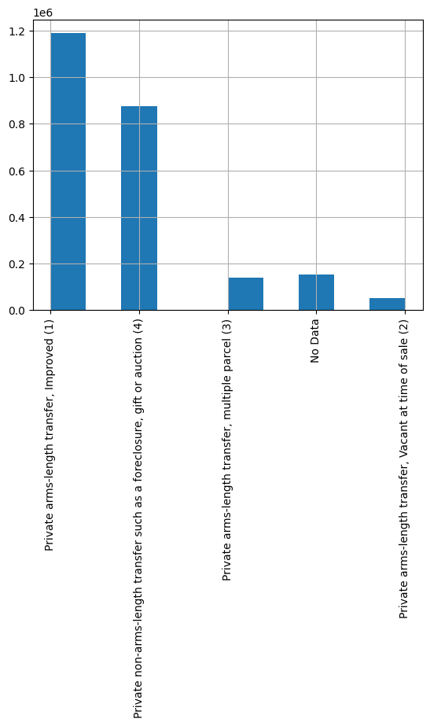

```python
estate_clean_df["SALES SEGMENT 1: How Conveyed Ind. (MDP Field: CONVEY1. SDAT Field #87)"].hist(xrot='vertical')
```

We don't need these conveyed columns, so let's remove them.

```python
for column in estate_clean_df.columns.to_list():
    if "conveyed" in column.lower():
        needed_columns.remove(column)
estate_clean_df=estate_df[needed_columns]
```

Now that we have the data we want, let's get to fully cleaning it so we can start the analysis.

First off, I want to change the column names so they are easier to access.

```python
estate_clean_df=estate_clean_df.rename({"MDP Street Address City (MDP Field: CITY)": "City",
                        "SALES SEGMENT 1: Transfer Date (YYYY.MM.DD) (MDP Field: TRADATE. SDAT Field #89)":"Sale_1_Date",
                        "SALES SEGMENT 1: Consideration (MDP Field: CONSIDR1. SDAT Field #90)":"Sale_1_Price",
                        "SALES SEGMENT 2: Transfer Date (YYYY.MM.DD) (SDAT Field #109)":"Sale_2_Date",
                        "SALES SEGMENT 2: Consideration (SDAT Field #110)":"Sale_2_Price",
                        "SALES SEGMENT 3: Transfer Date (YYYY.MM.DD) (SDAT Field #129)":"Sale_3_Date",
                        "SALES SEGMENT 3: Consideration (SDAT Field #130)":"Sale_3_Price",
                        "PRIOR ASSESSMENT YEAR: Total Assessment (SDAT Field #161)":"Last_Assessment",
                        "CURRENT ASSESSMENT YEAR: Total Assessment (SDAT Field #172)":"Current_Assessment",
                        "County Name (MDP Field: CNTYNAME)":"County",
                        "CURRENT CYCLE DATA: Date Assessed (YYYY.MM) (MDP Field: LASTASSD. SDAT Field #169)":"Current_Assessment_Date"},axis='columns')
estate_clean_df.head()
```

|  | City | Sale_1_Date | Sale_1_Price | Sale_2_Date | Sale_2_Price | Sale_3_Date | Sale_3_Price | Last_Assessment | Current_Assessment | County | Current_Assessment_Date |
| --- | --- | --- | --- | --- | --- | --- | --- | --- | --- | --- | --- |
| 0 | EARLEVILLE | 2019.10.25 | 35000.0 | 2007.05.08 | 0.0 | 0000.00.00 | 0.0 | 77300.0 | 77300.0 | Cecil County | 2022.01 |
| 1 | EARLEVILLE | 2002.12.20 | 0.0 | 2000.06.02 | 8000.0 | 0000.00.00 | 0.0 | 7800.0 | 7800.0 | Cecil County | 2022.01 |
| 2 | EARLEVILLE | 1991.04.05 | 62000.0 | 1987.12.03 | 0.0 | 0000.00.00 | 0.0 | 120867.0 | 122300.0 | Cecil County | 2022.01 |
| 3 | EARLEVILLE | 1991.04.05 | 62000.0 | 1987.12.03 | 0.0 | 0000.00.00 | 0.0 | 4900.0 | 4900.0 | Cecil County | 2022.01 |
| 4 | EARLEVILLE | 2022.06.07 | 0.0 | 2021.01.06 | 0.0 | 1992.12.08 | 0.0 | 179067.0 | 182200.0 | Cecil County | 2022.01 |

Now, let's fix the data types of all of the columns. Obviously, sale data should be seen as a number, city/county should be a string, and date should eventually be a datetime.

```python
estate_clean_df.info()
```

```
<class 'pandas.core.frame.DataFrame'>
RangeIndex: 2418154 entries, 0 to 2418153
Data columns (total 11 columns):
 #   Column                   Dtype
---  ------                   -----
 0   City                     object
 1   Sale_1_Date              object
 2   Sale_1_Price             float64
 3   Sale_2_Date              object
 4   Sale_2_Price             float64
 5   Sale_3_Date              object
 6   Sale_3_Price             float64
 7   Last_Assessment          float64
 8   Current_Assessment       float64
 9   County                   object
 10  Current_Assessment_Date  object
dtypes: float64(5), object(6)
memory usage: 202.9+ MB
```

```python
estate_clean_df[["City","Sale_1_Date","Sale_2_Date","Sale_3_Date","Current_Assessment_Date"]]=estate_clean_df[["City","Sale_1_Date","Sale_2_Date","Sale_3_Date","Current_Assessment_Date"]].astype(str)
estate_clean_df[["Sale_1_Price","Sale_2_Price","Sale_3_Price","Last_Assessment","Current_Assessment"]] = estate_clean_df[["Sale_1_Price","Sale_2_Price","Sale_3_Price","Last_Assessment","Current_Assessment"]].astype(float)
estate_clean_df.dropna(subset=["City","County"],how="all",inplace=True)
```

We will drop any rows that don't have any sales data, as well as any rows that do not have at least city or county information.

```python
# if BOTH city and county missing, then drop row
estate_clean_df=estate_clean_df[(estate_clean_df["City"]!="nan") & (estate_clean_df["County"]!="nan")]
```

```python
#drop rows where all sales data is null
estate_clean_df.dropna(subset=["Sale_1_Price","Sale_2_Price","Sale_3_Price","Last_Assessment","Current_Assessment"],how="all",inplace=True)
```

Let's see if we have any more null values.

```python
estate_clean_df.isna().sum()
```

```
City                        0
Sale_1_Date                 0
Sale_1_Price                0
Sale_2_Date                 0
Sale_2_Price                0
Sale_3_Date                 0
Sale_3_Price                0
Last_Assessment             0
Current_Assessment         11
County                      0
Current_Assessment_Date     0
dtype: int64
```

Let's see how many rows we have left after our cleaning.

```python
# Format: (rows, columns)
estate_clean_df.shape
```

```
(2361278, 11)
```

We will just drop the null values in current_assessment, as we have millions of datapoints and can spare 11 to avoid issues.

```python
estate_clean_df.dropna(subset=["Current_Assessment"],inplace=True)
```

```python
estate_clean_df.isna().sum()
```

```
City                       0
Sale_1_Date                0
Sale_1_Price               0
Sale_2_Date                0
Sale_2_Price               0
Sale_3_Date                0
Sale_3_Price               0
Last_Assessment            0
Current_Assessment         0
County                     0
Current_Assessment_Date    0
dtype: int64
```

Great! Now we have no null values and we will fix the dates in the date columns and convert them to datetimes.

```python
estate_clean_df[["Sale_1_Date","Current_Assessment_Date"]].tail(5)
```

|  | Sale_1_Date | Current_Assessment_Date |
| --- | --- | --- |
| 2416361 | 0000.00.00 | 2023.01 |
| 2416362 | 1999.12.10 | 2023.01 |
| 2416363 | 0000.00.00 | 2023.01 |
| 2416364 | 1999.12.10 | 2023.01 |
| 2416365 | 2019.08.28 | 2023.01 |

After some testing, it looks like we have some values that have a 0000.00.00 or 0.0 as a date. Let's fix that. If there is no current assessment date, or we do not have a sale date, then the row is of no use to us because we are concerned with data based on date differences. Let's see what we can do.

Let's take away all the null or 0 data from the current_assessment_date column.

```python
estate_clean_df=estate_clean_df[estate_clean_df["Current_Assessment_Date"]!="0.0"]
estate_clean_df=estate_clean_df[estate_clean_df["Current_Assessment_Date"]!="nan"]
```

```python
estate_clean_df.sample(3)
```

|  | City | Sale_1_Date | Sale_1_Price | Sale_2_Date | Sale_2_Price | Sale_3_Date | Sale_3_Price | Last_Assessment | Current_Assessment | County | Current_Assessment_Date |
| --- | --- | --- | --- | --- | --- | --- | --- | --- | --- | --- | --- |
| 1892994 | BALTIMORE | 2022.10.11 | 370000.0 | 2019.03.06 | 226000.0 | 0000.00.00 | 0.0 | 264967.0 | 311233.0 | Baltimore City | 2023.01 |
| 264424 | POOLESVILLE | 0000.00.00 | 0.0 | 0000.00.00 | 0.0 | 0000.00.00 | 0.0 | 1100.0 | 1100.0 | Montgomery County | 2022.01 |
| 1373042 | ANNAPOLIS | 2021.04.13 | 520000.0 | 2014.07.10 | 46000.0 | 2010.01.07 | 360000.0 | 10000.0 | 10000.0 | Anne Arundel County | 2024.01 |

Let's check if we have any data where we do not have an assessment past the most recent one. We do not want data that is not assessed

```python
estate_clean_df[(estate_clean_df["Last_Assessment"]==0.0) & (estate_clean_df["Current_Assessment"]>0)].shape
```

```
(65, 11)
```

This is a very small amount of data, so we will just remove it.

```python
estate_clean_df=estate_clean_df.drop(estate_clean_df[(estate_clean_df["Last_Assessment"]==0.0) & (estate_clean_df["Current_Assessment"]>0)].index)
```

Before going on to the next step, we need to clean up our date strings a little bit. To have proper formatting, we will assume that the current assessment date is on the 1st of every month.

```python
estate_clean_df["Current_Assessment_Date"]=estate_clean_df["Current_Assessment_Date"]+".01"
```

We know that assessments happen every 3 years in the state of Maryland. Therefore, we will make a new column called "Last_Assessment_Date" and make it 3 years before.

```python
estate_clean_df["Last_Assessment_Date"]=""
```

In order to have faster operations, we will create a dictionary of the dataframe and convert it back to a dataframe afterwards

```python
estate_clean_df_dict = estate_clean_df.to_dict('list')
```

```python
estate_clean_df_dict["Last_Assessment_Date"]=[]
for index, current_date in enumerate(estate_clean_df_dict["Current_Assessment_Date"]):
    estate_clean_df_dict["Last_Assessment_Date"].append(str(int(current_date[0:4])-3)+(current_date[4:]))
estate_clean_df_dict["Last_Assessment_Date"][0:5]
```

```
['2019.01.01', '2019.01.01', '2019.01.01', '2019.01.01', '2019.01.01']
```

Ok, now we are ready for our final real estate dataset. What we care about is the year of the evaluation/sale/price of the property from one evaluation/sale/price to the next. The final dataset is going to be measuring one price to the next with the year of sale from that price to the next. We will grab the values that we need and put them into a dictionary with lists for each column (in order), so that we can create a final dataframe from the dictionary, suited to our needs.

```python
# This function takes in the individual values for a datapoint, and essentially creates a row of the dataframe with the values.
def reconstruct_dataframe(reconstructed_dict, city, county, date1, date2, price, final_price):
    # We will also turn all of the cities into camel case while we have easy access to this raw data
    city_word_list = city.split(" ")
    my_city_string=""
    for word in city_word_list:
        if (word !=""):
            my_city_string=word[0].upper()+word[1:].lower()+ " "
    my_city_string=my_city_string[:-1]
    reconstructed_dict["City"].append(my_city_string)
    reconstructed_dict["County"].append(county)
    reconstructed_dict["Date_1"].append(date1)
    reconstructed_dict["Date_2"].append(date2)
    reconstructed_dict["Price"].append(price)
    reconstructed_dict["Final_Price"].append(final_price)

# Create a blank dictionary, and put blank lists for each field (column)
reconstructed_dict={}
reconstructed_dict["City"]=[]
reconstructed_dict["County"]=[]
reconstructed_dict["Date_1"]=[]
reconstructed_dict["Date_2"]=[]
reconstructed_dict["Price"]=[]
reconstructed_dict["Final_Price"]=[]

# Number of rows in new dataframe so far
count=0

# Loop through the dataframe
for index in range(0,len(estate_clean_df_dict["Current_Assessment_Date"])):

    # Add the city and county for every new row
    city=estate_clean_df_dict["City"][index]
    county=estate_clean_df_dict["County"][index]

    """ Explanation of if logic:
            The most recent sale is always going to be in Sale_1_Date. The second most recent in Sale_2. The third most recent in Sale_3.
            If Sale_1 is not null, check Sale_2. If Sale_2 is not null, check Sale_3. Then, add the sales in order to the dictionary.
            Finally, add a row that will be from the last assessment to the current assessment, which should always be valid (based on our cleaning).
    """

    if (estate_clean_df_dict["Sale_1_Date"][index]!="0000.00.00"):
        if (estate_clean_df_dict["Sale_2_Date"][index]!="0000.00.00"):
            reconstruct_dataframe(reconstructed_dict,city,county,estate_clean_df_dict["Sale_2_Date"][index],estate_clean_df_dict["Sale_1_Date"][index],estate_clean_df_dict["Sale_2_Price"][index],estate_clean_df_dict["Sale_1_Price"][index])
            count=count+1
            if (estate_clean_df_dict["Sale_3_Date"][index]!="0000.00.00"):
                reconstruct_dataframe(reconstructed_dict,city,county,estate_clean_df_dict["Sale_3_Date"][index],estate_clean_df_dict["Sale_2_Date"][index],estate_clean_df_dict["Sale_3_Price"][index],estate_clean_df_dict["Sale_2_Price"][index])
                count=count+1

            # Make sure that if the most recent sale is after the last assessment, that the order is correct
            elif (estate_clean_df_dict["Sale_1_Date"][index]>estate_clean_df_dict["Last_Assessment_Date"][index]):
                    reconstruct_dataframe(reconstructed_dict,city,county,estate_clean_df_dict["Last_Assessment_Date"][index],estate_clean_df_dict["Sale_1_Date"][index],estate_clean_df_dict["Last_Assessment"][index],estate_clean_df_dict["Sale_1_Price"][index])
            else:
                reconstruct_dataframe(reconstructed_dict,city,county,estate_clean_df_dict["Sale_1_Date"][index],estate_clean_df_dict["Last_Assessment_Date"][index],estate_clean_df_dict["Sale_1_Price"][index],estate_clean_df_dict["Last_Assessment"][index])
                count=count+1
        # Make sure that if the most recent sale is after the last assessment, that the order is correct
        elif (estate_clean_df_dict["Sale_1_Date"][index]>estate_clean_df_dict["Last_Assessment_Date"][index]):
                    reconstruct_dataframe(reconstructed_dict,city,county,estate_clean_df_dict["Last_Assessment_Date"][index],estate_clean_df_dict["Sale_1_Date"][index],estate_clean_df_dict["Last_Assessment"][index],estate_clean_df_dict["Sale_1_Price"][index])
        else:
            reconstruct_dataframe(reconstructed_dict,city,county,estate_clean_df_dict["Sale_1_Date"][index],estate_clean_df_dict["Last_Assessment_Date"][index],estate_clean_df_dict["Sale_1_Price"][index],estate_clean_df_dict["Last_Assessment"][index])
            count=count+1

    reconstruct_dataframe(reconstructed_dict,city,county,estate_clean_df_dict["Last_Assessment_Date"][index],estate_clean_df_dict["Current_Assessment_Date"][index],estate_clean_df_dict["Last_Assessment"][index],estate_clean_df_dict["Current_Assessment"][index])
    count=count+1
```

Ok, now we will go back from a dictionary to a dataframe.

```python
final_estate_df = pd.DataFrame.from_dict(reconstructed_dict)
```

```python
final_estate_df.head(5)
```

|  | City | County | Date_1 | Date_2 | Price | Final_Price |
| --- | --- | --- | --- | --- | --- | --- |
| 0 | Earleville | Cecil County | 2007.05.08 | 2019.10.25 | 0.0 | 35000.0 |
| 1 | Earleville | Cecil County | 2019.01.01 | 2019.10.25 | 77300.0 | 35000.0 |
| 2 | Earleville | Cecil County | 2019.01.01 | 2022.01.01 | 77300.0 | 77300.0 |
| 3 | Earleville | Cecil County | 2000.06.02 | 2002.12.20 | 8000.0 | 0.0 |
| 4 | Earleville | Cecil County | 2002.12.20 | 2019.01.01 | 0.0 | 7800.0 |

We will now change the dates in the dataframe to a datetime and then extract only the year (because our crime data is based on year).

```python
final_estate_df["Date_1"]=pd.to_datetime(final_estate_df["Date_1"])
final_estate_df["Date_2"]=pd.to_datetime(final_estate_df["Date_2"])
final_estate_df["Date_1"]=final_estate_df["Date_1"].dt.year
final_estate_df["Date_2"]=final_estate_df["Date_2"].dt.year
```

If the data is from the same year, there is no change in time according to the data, so we can remove those rows.

```python
final_estate_df = final_estate_df[final_estate_df["Date_1"]!=final_estate_df["Date_2"]]
```

Great! Now let's move onto the crime dataset.

#### Crime Data

Let's see what sort of columns we have in our crime dataset.

```python
crime_df.columns
```

```
Index(['JURISDICTION', 'COUNTY', 'YEAR', 'POPULATION', 'MURDER', 'RAPE',
       'ROBBERY', 'AGG. ASSAULT', 'B & E', 'LARCENY THEFT', 'M/V THEFT',
       'GRAND TOTAL', 'PERCENT CHANGE', 'VIOLENT CRIME TOTAL',
       'VIOLENT CRIME PERCENT', 'VIOLENT CRIME PERCENT CHANGE',
       'PROPERTY CRIME TOTALS', 'PROPERTY CRIME PERCENT',
       'PROPERTY CRIME PERCENT CHANGE',
       'OVERALL CRIME RATE PER 100,000 PEOPLE',
       'OVERALL PERCENT CHANGE PER 100,000 PEOPLE',
       'VIOLENT CRIME RATE PER 100,000 PEOPLE',
       'VIOLENT CRIME RATE PERCENT CHANGE PER 100,000 PEOPLE',
       'PROPERTY CRIME RATE PER 100,000 PEOPLE',
       'PROPERTY CRIME RATE PERCENT CHANGE PER 100,000 PEOPLE',
       'MURDER PER 100,000 PEOPLE', 'RAPE PER 100,000 PEOPLE',
       'ROBBERY PER 100,000 PEOPLE', 'AGG. ASSAULT PER 100,000 PEOPLE',
       'B & E PER 100,000 PEOPLE', 'LARCENY THEFT PER 100,000 PEOPLE',
       'M/V THEFT PER 100,000 PEOPLE'],
      dtype='object')
```

```python
crime_df["COUNTY"].unique()
```

```
array(['Dorchester', 'Caroline', 'Washington', 'Garrett', 'Allegany',
       'Harford', 'Anne Arundel', 'Baltimore City', "Queen Anne's",
       'Montgomery', 'Worcester', "Prince George's", 'Kent', 'Frederick',
       'Cecil', 'Calvert', 'Somerset', 'Wicomico', 'Talbot', 'Carroll',
       'Charles', "St. Mary's"], dtype=object)
```

We are missing Baltimore and Howard counties! Let's add this data, so we at least have county crime data.

```python
bal_how_crime_df=pd.read_csv('Violent_Crime___Property_Crime_by_County__1975_to_Present_20240706.csv')
bal_how_crime_df["COUNTY"]=bal_how_crime_df["JURISDICTION"]
bal_how_crime_df.loc[bal_how_crime_df["COUNTY"]=="Howard County","COUNTY"]="Howard"
bal_how_crime_df.loc[bal_how_crime_df["COUNTY"]=="Baltimore County","COUNTY"]="Baltimore"
bal_how_crime_df.drop("JURISDICTION",inplace=True,axis='columns')
crime_df=pd.concat([crime_df,bal_how_crime_df])
```

```python
crime_df[crime_df["COUNTY"]=="Howard"].sample(2)
```

|  | JURISDICTION | COUNTY | YEAR | POPULATION | MURDER | RAPE | ROBBERY | AGG. ASSAULT | B & E | LARCENY THEFT | ... | B & E PER 100,000 PEOPLE | LARCENY THEFT PER 100,000 PEOPLE | M/V THEFT PER 100,000 PEOPLE | MURDER RATE PERCENT CHANGE PER 100,000 PEOPLE | RAPE RATE PERCENT CHANGE PER 100,000 PEOPLE | ROBBERY RATE PERCENT CHANGE PER 100,000 PEOPLE | AGG. ASSAULT RATE PERCENT CHANGE PER 100,000 PEOPLE | B & E RATE PERCENT CHANGE PER 100,000 PEOPLE | LARCENY THEFT RATE PERCENT CHANGE PER 100,000 PEOPLE | M/V THEFT RATE PERCENT CHANGE PER 100,000 PEOPLE |
| --- | --- | --- | --- | --- | --- | --- | --- | --- | --- | --- | --- | --- | --- | --- | --- | --- | --- | --- | --- | --- | --- |
| 31 | NaN | Howard | 1990 | 187328 | 7 | 50 | 99 | 433 | 1802 | 4899 | ... | 961.9 | 2615.2 | 532.2 | -38.1 | 57.8 | -47.6 | 5.1 | -5.8 | -15.4 | -5.3 |
| 53 | NaN | Howard | 2012 | 295972 | 5 | 33 | 178 | 364 | 1185 | 4921 | ... | 400.4 | 1662.7 | 105.8 | -18.4 | -2.1 | -18.9 | 0.7 | 4.5 | -5.4 | -18.1 |

2 rows × 39 columns

Ok, let's go back to the columns. So we don't really need the columns that aren't percent based (but we will keep population and grand total for some charts later), and in this way, we will have some sort of normalization. Let's get rid of the columns we don't need. Let's also get rid of the percent changes. We can calculate that ourselves if need be.

```python
needed_columns=crime_df.columns.to_list()
for rem_col in ["MURDER","RAPE","ROBBERY","AGG. ASSAULT", "B & E", "LARCENY THEFT", "M/V THEFT","VIOLENT CRIME TOTAL", "PROPERTY CRIME TOTALS"]:
    needed_columns.remove(rem_col)
needed_columns_hold=needed_columns.copy()
for column in needed_columns_hold:
    if "change" in column.lower():
        needed_columns.remove(column)
crime_clean_df=crime_df[needed_columns]
```

Now, let's see what datatypes are in our dataframe, and let's make sure that all of the data has the correct type.

```python
crime_clean_df.info()
```

```
<class 'pandas.core.frame.DataFrame'>
Index: 4346 entries, 0 to 61
Data columns (total 17 columns):
 #   Column                                  Non-Null Count  Dtype
---  ------                                  --------------  -----
 0   JURISDICTION                            4284 non-null   object
 1   COUNTY                                  4346 non-null   object
 2   YEAR                                    4346 non-null   int64
 3   POPULATION                              4346 non-null   int64
 4   GRAND TOTAL                             4346 non-null   int64
 5   VIOLENT CRIME PERCENT                   4346 non-null   float64
 6   PROPERTY CRIME PERCENT                  4346 non-null   float64
 7   OVERALL CRIME RATE PER 100,000 PEOPLE   4345 non-null   float64
 8   VIOLENT CRIME RATE PER 100,000 PEOPLE   4346 non-null   float64
 9   PROPERTY CRIME RATE PER 100,000 PEOPLE  4346 non-null   float64
 10  MURDER PER 100,000 PEOPLE               4346 non-null   float64
 11  RAPE PER 100,000 PEOPLE                 4346 non-null   float64
 12  ROBBERY PER 100,000 PEOPLE              4346 non-null   float64
 13  AGG. ASSAULT PER 100,000 PEOPLE         4346 non-null   float64
 14  B & E PER 100,000 PEOPLE                4346 non-null   float64
 15  LARCENY THEFT PER 100,000 PEOPLE        4346 non-null   float64
 16  M/V THEFT PER 100,000 PEOPLE            4346 non-null   float64
dtypes: float64(12), int64(3), object(2)
memory usage: 611.2+ KB
```

```python
%%capture
crime_clean_df[["JURISDICTION","COUNTY"]]=crime_clean_df[["JURISDICTION","COUNTY"]].astype(str)
crime_clean_df[["YEAR","POPULATION"]]=crime_clean_df[["YEAR","POPULATION"]].astype(int)
crime_clean_df[["VIOLENT CRIME PERCENT","PROPERTY CRIME PERCENT","OVERALL CRIME RATE PER 100,000 PEOPLE",
                "VIOLENT CRIME RATE PER 100,000 PEOPLE","PROPERTY CRIME RATE PER 100,000 PEOPLE","MURDER PER 100,000 PEOPLE",
                "RAPE PER 100,000 PEOPLE","ROBBERY PER 100,000 PEOPLE","AGG. ASSAULT PER 100,000 PEOPLE","B & E PER 100,000 PEOPLE",
                "LARCENY THEFT PER 100,000 PEOPLE","M/V THEFT PER 100,000 PEOPLE"]]=crime_clean_df[["VIOLENT CRIME PERCENT","PROPERTY CRIME PERCENT","OVERALL CRIME RATE PER 100,000 PEOPLE",
                "VIOLENT CRIME RATE PER 100,000 PEOPLE","PROPERTY CRIME RATE PER 100,000 PEOPLE","MURDER PER 100,000 PEOPLE",
                "RAPE PER 100,000 PEOPLE","ROBBERY PER 100,000 PEOPLE","AGG. ASSAULT PER 100,000 PEOPLE","B & E PER 100,000 PEOPLE",
                "LARCENY THEFT PER 100,000 PEOPLE","M/V THEFT PER 100,000 PEOPLE"]].astype(float)
```

Let's rename some columns so that they are easier to access later and follow the same formatting as the real estate dataframe.

```python
crime_clean_df=crime_clean_df.rename({"JURISDICTION":"Jurisdiction",
                       "COUNTY":"County",
                        "YEAR":"Year",
                       "VIOLENT CRIME PERCENT":"Violent_Crime_Percent",
                       "PROPERTY CRIME PERCENT":"Property_Crime_Percent",
                       "OVERALL CRIME RATE PER 100,000 PEOPLE":"Overall_Rate_Per_100k",
                       "VIOLENT CRIME RATE PER 100,000 PEOPLE":"Violent_Rate_Per_100k",
                       "PROPERTY CRIME RATE PER 100,000 PEOPLE":"Property_Rate_Per_100k",
                       "MURDER PER 100,000 PEOPLE":"Murder_Per_100k",
                        "RAPE PER 100,000 PEOPLE":"Rape_Per_100k",
                        "ROBBERY PER 100,000 PEOPLE":"Robbery_Per_100k",
                        "AGG. ASSAULT PER 100,000 PEOPLE":"Agg_Assault_Per_100k",
                        "B & E PER 100,000 PEOPLE":"BNE_Per_100k",
                       "LARCENY THEFT PER 100,000 PEOPLE":"Larceny_Per_100k",
                       "M/V THEFT PER 100,000 PEOPLE":"MV_Theft_Per_100k",
                        "GRAND TOTAL":"Grand_Total",
                        "POPULATION":"Population"},axis='columns')
;
```

```
''
```

```python
crime_clean_df.sample(3)
```

|  | Jurisdiction | County | Year | Population | Grand_Total | Violent_Crime_Percent | Property_Crime_Percent | Overall_Rate_Per_100k | Violent_Rate_Per_100k | Property_Rate_Per_100k | Murder_Per_100k | Rape_Per_100k | Robbery_Per_100k | Agg_Assault_Per_100k | BNE_Per_100k | Larceny_Per_100k | MV_Theft_Per_100k |
| --- | --- | --- | --- | --- | --- | --- | --- | --- | --- | --- | --- | --- | --- | --- | --- | --- | --- |
| 3610 | Sharpsburg | Washington | 2009 | 662 | 11 | 0.0 | 100.0 | 1661.6 | 0.0 | 1661.6 | 0.0 | 0.0 | 0.0 | 0.0 | 906.3 | 755.3 | 0.0 |
| 1249 | Eagle Harbor | Prince George's | 2020 | 65 | 0 | 0.0 | 0.0 | 0.0 | 0.0 | 0.0 | 0.0 | 0.0 | 0.0 | 0.0 | 0.0 | 0.0 | 0.0 |
| 4171 | Westminster | Carroll | 2001 | 16980 | 822 | 7.5 | 92.5 | 4841.0 | 365.1 | 4475.9 | 0.0 | 17.7 | 94.2 | 253.2 | 718.5 | 3586.6 | 170.8 |

Let's see what years we have available from the crime data.

```python
print(crime_clean_df["Year"].max())
print(crime_clean_df["Year"].min())
```

```
2020
1990
```

Ok, so it seems that our year data only goes up to 2020. I will manually enter data (by county) from the 2021 and 2022 Maryland State Uniform Crime Reports. https://mdsp.maryland.gov/Pages/Documents,%20Forms,%20Publications,%20and%20Proactive%20Releases.aspx Since we also need population data, we will take it from the Census data and predictions. https://msa.maryland.gov/msa/mdmanual/01glance/html/pop.html. The formula used to calculate the 2021 population was (2030 prediction - 2020 population)*.1 + 2020 population, and the 2022 estimate was (2030 prediction - 2020 population)*.2 + 2020 population.

That was a lot of manual entry, but it should allow us to have crime data, at least by county, for 2021 and 2022.

```python
# My manually entered data. Yes it took forever.
my_extra_crime = pd.read_csv('Crime_Data_Maryland_2021-2022.csv')
```

```python
new_crime_df=pd.concat([crime_clean_df,my_extra_crime])
new_crime_df[new_crime_df["Year"]==2021].sample(3)
```

|  | Jurisdiction | County | Year | Population | Grand_Total | Violent_Crime_Percent | Property_Crime_Percent | Overall_Rate_Per_100k | Violent_Rate_Per_100k | Property_Rate_Per_100k | Murder_Per_100k | Rape_Per_100k | Robbery_Per_100k | Agg_Assault_Per_100k | BNE_Per_100k | Larceny_Per_100k | MV_Theft_Per_100k |
| --- | --- | --- | --- | --- | --- | --- | --- | --- | --- | --- | --- | --- | --- | --- | --- | --- | --- |
| 12 | NaN | Carroll | 2021 | 173017 | 1464 | 16.5 | 83.5 | 846.2 | 139.9 | 706.3 | 0.6 | 20.8 | 9.8 | 108.7 | 85.5 | 587.8 | 32.9 |
| 30 | NaN | Montgomery | 2021 | 1068334 | 15948 | 12.7 | 87.3 | 1492.8 | 189.1 | 1303.7 | 3.2 | 39.9 | 45.7 | 100.3 | 103.1 | 1073.3 | 127.4 |
| 28 | NaN | Kent | 2021 | 19368 | 202 | 15.3 | 84.7 | 1042.9 | 160.1 | 882.9 | 0.0 | 20.7 | 51.6 | 87.8 | 273.6 | 588.6 | 20.7 |

Let's make sure all the types are still correct.

```python
%%capture
new_crime_df[["Jurisdiction","County"]]=new_crime_df[["Jurisdiction","County"]].astype(str)
new_crime_df[["Year","Population"]]=new_crime_df[["Year","Population"]].astype(int)
new_crime_df[["Violent_Crime_Percent","Property_Crime_Percent","Overall_Rate_Per_100k",
                "Violent_Rate_Per_100k","Property_Rate_Per_100k","Murder_Per_100k",
                "Rape_Per_100k","Robbery_Per_100k","Agg_Assault_Per_100k","BNE_Per_100k",
                "Larceny_Per_100k","MV_Theft_Per_100k"]]=new_crime_df[["Violent_Crime_Percent","Property_Crime_Percent","Overall_Rate_Per_100k",
                "Violent_Rate_Per_100k","Property_Rate_Per_100k","Murder_Per_100k",
                "Rape_Per_100k","Robbery_Per_100k","Agg_Assault_Per_100k","BNE_Per_100k",
                "Larceny_Per_100k","MV_Theft_Per_100k"]].astype(float)
```

```python
final_crime_df=new_crime_df
```

#### Inflation Data

Let's see what sort of data we have in our inflation dataframe.

```python
inflation_df.info()
```

```
<class 'pandas.core.frame.DataFrame'>
RangeIndex: 918 entries, 0 to 917
Data columns (total 2 columns):
 #   Column  Non-Null Count  Dtype
---  ------  --------------  -----
 0   date    918 non-null    object
 1   value   918 non-null    float64
dtypes: float64(1), object(1)
memory usage: 14.5+ KB
```

```python
inflation_df.head(3)
```

|  | date | value |
| --- | --- | --- |
| 0 | 1947-01-01 | 21.48 |
| 1 | 1947-02-01 | 21.62 |
| 2 | 1947-03-01 | 22.00 |

Since the rest of our data is based on year, we will use the inflation data for the start of each year.

```python
# Create dictionary to reconstruct this dataframe
reconstructed_inflation = {}
reconstructed_inflation["Date"]=[]
reconstructed_inflation["Inflation_Index"]=[]

# Loop through dataframe
for index, row in inflation_df.iterrows():
    # If start of year data (jan 1), keep
    if (row["date"][-5:]=="01-01"):
        reconstructed_inflation["Date"].append(row["date"][0:4])
        reconstructed_inflation["Inflation_Index"].append(int(row["value"]))
inflation_clean_df = pd.DataFrame.from_dict(reconstructed_inflation)
inflation_clean_df.head()
```

|  | Date | Inflation_Index |
| --- | --- | --- |
| 0 | 1947 | 21 |
| 1 | 1948 | 23 |
| 2 | 1949 | 24 |
| 3 | 1950 | 23 |
| 4 | 1951 | 25 |

```python
final_inflation_df=inflation_clean_df
```

#### Conclusion of Section

Ok! Now we are officially done with cleaning! Yippee!

Later, we will combine our datasets into one, but we have to do some analysis first to understand our features better.

## Data Exploration

First, I want to take a look at the crime dataset.

```python
final_crime_df.sample(5)
```

|  | Jurisdiction | County | Year | Population | Grand_Total | Violent_Crime_Percent | Property_Crime_Percent | Overall_Rate_Per_100k | Violent_Rate_Per_100k | Property_Rate_Per_100k | Murder_Per_100k | Rape_Per_100k | Robbery_Per_100k | Agg_Assault_Per_100k | BNE_Per_100k | Larceny_Per_100k | MV_Theft_Per_100k |
| --- | --- | --- | --- | --- | --- | --- | --- | --- | --- | --- | --- | --- | --- | --- | --- | --- | --- |
| 2797 | New Carrollton | Prince George's | 1997 | 12002 | 617 | 11.7 | 88.3 | 5140.8 | 599.9 | 4540.9 | 8.3 | 25.0 | 283.3 | 283.3 | 758.2 | 2482.9 | 1299.8 |
| 1971 | Hancock | Washington | 1997 | 2485 | 59 | 28.8 | 71.2 | 2374.2 | 684.1 | 1690.1 | 0.0 | 0.0 | 0.0 | 684.1 | 362.2 | 1327.9 | 0.0 |
| 3790 | Sudlersville | Queen Anne's | 2006 | 391 | 12 | 8.3 | 91.7 | 3069.1 | 255.8 | 2813.3 | 0.0 | 0.0 | 0.0 | 255.8 | 1023.0 | 1278.8 | 511.5 |
| 3077 | Oxford | Talbot | 2020 | 606 | 0 | 0.0 | 0.0 | 0.0 | 0.0 | 0.0 | 0.0 | 0.0 | 0.0 | 0.0 | 0.0 | 0.0 | 0.0 |
| 3167 | Pocomoke City | Worcester | 2018 | 4042 | 165 | 6.1 | 93.9 | 4082.1 | 247.4 | 3834.7 | 0.0 | 74.2 | 123.7 | 49.5 | 791.7 | 2944.1 | 99.0 |

Notice that violent crime and property crime percent are inversely proportional. Therefore, we can get rid of one of them because having two of essentially same features in a model is not helpful. We will get rid of these later.

I wonder if different jurisdictions within a county have significantly different crime rates. This is important for us to know because we currently plan to check crime rates based on the jurisdiction and not county (unless we cannot find the jurisdiction in the housing dataset).

We will thus perform a hypothesis test to check the statistical significance. Note our alpha value is .05, which means we want it to be so that when samples of this size are taken, at most 5% of the time, if the null hypothesis were true, the values would fall into this range. Such a low percentage allows us to reject the null hypothesis.

#### Hypothesis Test for Crime Data

H<sub>0</sub> (null): There is no statistical difference in crime rates between jurisdictions and the general county

H<sub>a</sub> (alternative): There is a statistical difference in crime rates between jurisdictions and the general county

alpha=.05

We will be using a one-sample t-test as we have one variable, and we are comparing to a known population mean.

```python
county_averages={}
county_population={}
county_total_crime={}
for index, row in final_crime_df.iterrows():
    if row["County"] in county_total_crime.keys():
        county_total_crime[row["County"]]=county_total_crime[row["County"]]+row["Grand_Total"]
        county_population[row["County"]]=county_population[row["County"]]+row["Population"]
    else:
        county_total_crime[row["County"]]=row["Grand_Total"]
        county_population[row["County"]]=row["Population"]
for county in county_population.keys():
    county_averages[county]=county_total_crime[county]/county_population[county]
county_averages
```

```
{'Dorchester': 0.062108883316649655,
 'Caroline': 0.04047327308929392,
 'Washington': 0.0348980964392045,
 'Garrett': 0.022801118331570197,
 'Allegany': 0.04659882750739129,
 'Harford': 0.03436342511838421,
 'Anne Arundel': 0.03637563088250946,
 'Baltimore City': 0.08479601901689911,
 "Queen Anne's": 0.01725235425965719,
 'Montgomery': 0.02591954652810581,
 'Worcester': 0.09780827836552032,
 "Prince George's": 0.04441255300800645,
 'Kent': 0.0285126040876736,
 'Frederick': 0.028464862816212282,
 'Cecil': 0.05124862131075115,
 'Calvert': 0.017701831016019336,
 'Somerset': 0.0462698923742066,
 'Wicomico': 0.07013505296531881,
 'Talbot': 0.04032870953606836,
 'Carroll': 0.027045679745460717,
 'Charles': 0.026312686910512997,
 "St. Mary's": 0.022670935925290146,
 'Baltimore': 0.04311458677737528,
 'Howard': 0.027367700379156375}
```

Let's take a look at crime by county, just to get an idea of which counties have the highest crime rates.

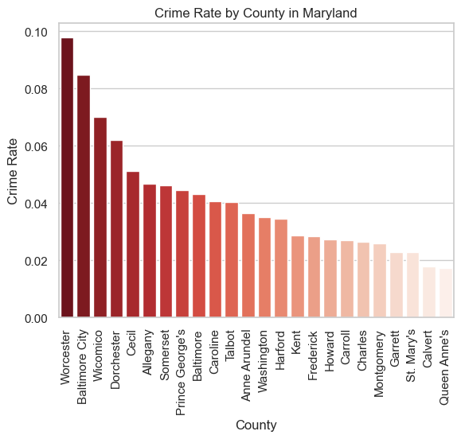

```python
sorted_counties = sorted(county_averages.items(), key=lambda x:x[1],reverse=True)
my_county_list=[]
my_value_list=[]
for county in sorted_counties:
    my_county_list.append(county[0])
for value in sorted_counties:
    my_value_list.append(value[1])
graph_df=pd.DataFrame({"County":my_county_list,"Crime Rate":my_value_list});

sns.set(style="whitegrid", color_codes=True)
seabornAxHandle = sns.barplot(x="County",y="Crime Rate", data=graph_df,hue="County",palette="Reds_r")
plt.pyplot.xticks(rotation=90)
plt.pyplot.title("Crime Rate by County in Maryland")
plt.pyplot.show() # Vertical bars with horizontal gradient
```

Let's add a field for every single jurisdiction / county. We will call this field the crime percentage, or the crime rate in that jurisdiction / county. It will be calculated on a per-entry basis in the dataframe.

```python
final_crime_df["Crime_Percent"]=(final_crime_df["Grand_Total"]/final_crime_df["Population"]).astype(float)
```

```python
for county in county_averages.keys():
    print(county+": "+str(ttest_1samp(final_crime_df[(final_crime_df["County"]==county)]["Crime_Percent"],popmean=county_averages[county]).pvalue))
```

```
Dorchester: 3.9773669501752947e-23
Caroline: 1.122827729000511e-07
Washington: 4.777225977929075e-37
Garrett: 0.05252627832298904
Allegany: 5.201375443634442e-32
Harford: 4.539714358795862e-09
Anne Arundel: 0.00012693065080313158
Baltimore City: 0.7061525679753834
Queen Anne's: 0.2400688706065139
Montgomery: 0.005627131968936464
Worcester: 0.09819426548546821
Prince George's: 1.54714909736989e-28
Kent: 5.223648014813827e-08
Frederick: 4.839471773458311e-36
Cecil: 1.4435793165665393e-20
Calvert: 1.6809604956855852e-11
Somerset: 0.0126023614426902
Wicomico: 4.1994628240006546e-42
Talbot: 0.00047591427827583453
Carroll: 0.001591575297447596
Charles: 1.942651177538742e-06
St. Mary's: 3.871293268337056e-06
Baltimore: 0.7350556433207285
Howard: 0.346266582606933
```

#### Exploring home prices by county (over the years)

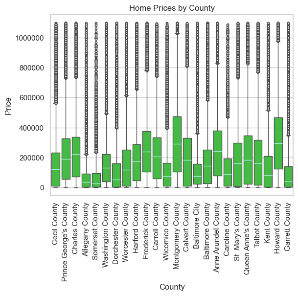

```python
outlier_prevent_df=final_estate_df[final_estate_df["Price"] < 1100000]
ax = sns.boxplot(outlier_prevent_df,x="County",y="Price",color="Limegreen",medianprops=dict(color="paleturquoise", alpha=0.9),flierprops = dict(markerfacecolor='0.9', markersize=3))
ax.ticklabel_format(style='plain', axis="y")
plt.pyplot.xticks(rotation=90)
plt.pyplot.title("Home Prices by County")
plt.pyplot.show()
```

Ok, so there are a lot of things going on with this plot. We can clearly see that every category has a huuuuuuge amount of outliers. Some of these outliers range into the hundreds of millions. Obviously, no home costs 900 million (which is one of the outliers, when you do the max function), so we will have to look at these outliers and identify which ones that we will keep.

How is an outlier defined in this case, and how do we even read a box and whisker plot? Well, the line that we see in the middle of each box defines where the median value in the set of values is. So for example, the median value (or value at the 50% mark, when arranging the values in order) is about 290,000. The edges of the green box mark the 25% of values and 75% values respectfully. So for the bottom line, 25% of all values would have a value at or below that one. For the top line, 75% of all values would have a value at or below that one. For the lines that shoot out of the box, those mark values that are not within this 25-75% range, but are not considered outliers. Usually, the values that are considered outliers are above or below the edges of the box and go out by an additional amount that is the the difference between the 25 and 75% mark, multiplied by 1.5 (called the interquartile range, multiplied by 1.5). We can see that above this 1.5*interquartile_range above the 75% mark (called the upper fence), there are a lot of values. This dataset has a lot of outliers in every single county. We need to come up with a way to deal with them so that way we can still build a useful model, as they will throw off the data.

Thankfully, however, we do not have any outliers below the box, so we only need to deal with values that are extremely high. I will likely filter out some of these outliers based on some sort of upper-value threshhold--especially because they are likely part of a multi-home deal. We want to be able to predict the change in the house prices, and we can't track the changes of multi-home deals.

#### Initial Anslysis of Crime Rates Relating to Housing Prices

Now I want to take a look at what we're actually here for: real estate value compared to crime rates. Let's see if we have some correlation between crime rates and house prices.

```python
# Create a dictionary to hold the crime and price data
my_crime_dict = {}
my_crime_dict["Price"]=[]
my_crime_dict["Property_Rate_Per_100k"]=[]
my_crime_dict["Murder_Per_100k"]=[]
my_crime_dict["Rape_Per_100k"]=[]
my_crime_dict["Robbery_Per_100k"]=[]
my_crime_dict["Agg_Assault_Per_100k"]=[]
my_crime_dict["BNE_Per_100k"]=[]
my_crime_dict["Larceny_Per_100k"]=[]
my_crime_dict["MV_Theft_Per_100k"]=[]
my_crime_dict["Crime_Percent"]=[]
# Loop through every county
for county in final_crime_df["County"].unique():
    # Loop through every year from 2015-2019
    for year in range(2015,2020):
        # Every county but baltimore city has the word county after it in the final estate df
        if (county != "Baltimore City"):
            my_crime_dict["Price"].append(final_estate_df[(final_estate_df["County"]==county+" County") & (final_estate_df["Date_1"]==year)]["Price"].median())
        else:
            my_crime_dict["Price"].append(final_estate_df[(final_estate_df["County"]==county) & (final_estate_df["Date_1"]==year)]["Price"].median())
        my_crime_dict["Property_Rate_Per_100k"].append(final_crime_df[(final_crime_df["County"]==county) & (final_crime_df["Year"]==year)]["Property_Rate_Per_100k"].median())
        my_crime_dict["Murder_Per_100k"].append(final_crime_df[(final_crime_df["County"]==county) & (final_crime_df["Year"]==year)]["Murder_Per_100k"].median())
        my_crime_dict["Rape_Per_100k"].append(final_crime_df[(final_crime_df["County"]==county) & (final_crime_df["Year"]==year)]["Rape_Per_100k"].median())
        my_crime_dict["Robbery_Per_100k"].append(final_crime_df[(final_crime_df["County"]==county) & (final_crime_df["Year"]==year)]["Robbery_Per_100k"].median())
        my_crime_dict["Agg_Assault_Per_100k"].append(final_crime_df[(final_crime_df["County"]==county) & (final_crime_df["Year"]==year)]["Agg_Assault_Per_100k"].median())
        my_crime_dict["BNE_Per_100k"].append(final_crime_df[(final_crime_df["County"]==county) & (final_crime_df["Year"]==year)]["BNE_Per_100k"].median())
        my_crime_dict["Larceny_Per_100k"].append(final_crime_df[(final_crime_df["County"]==county) & (final_crime_df["Year"]==year)]["Larceny_Per_100k"].median())
        my_crime_dict["MV_Theft_Per_100k"].append(final_crime_df[(final_crime_df["County"]==county) & (final_crime_df["Year"]==year)]["MV_Theft_Per_100k"].median())
        my_crime_dict["Crime_Percent"].append(final_crime_df[(final_crime_df["County"]==county) & (final_crime_df["Year"]==year)]["Crime_Percent"].median())
```

Now we should be ready for the plot.

```python
my_crime_df = pd.DataFrame.from_dict(my_crime_dict)
correlation = my_crime_df.corr()
```

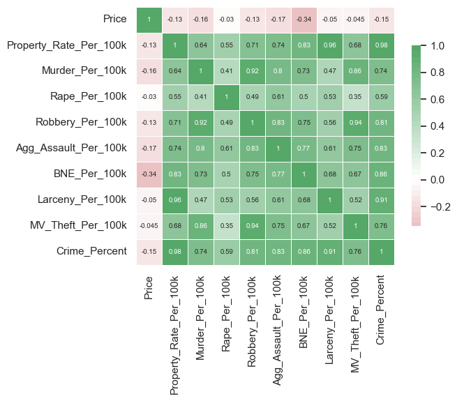

```python
f, ax = plt.pyplot.subplots()
# We will use seaborn's heatmap function, and use coloring so that the strongest correlation is a darker green, and strongest negative is darker red
sns.heatmap(correlation,annot=True,cmap=plt.colors.LinearSegmentedColormap.from_list('rg',["r", "w", "g"], N=50), center=0,
            square=True, linewidths=.5, cbar_kws={"shrink": .7},annot_kws={"fontsize":7})
```

This map shows us some very interesting data! A correlation heatmap like this uses color and values to show the correlation between two variables. There is a lot of different strong correlations between levels of crimes. When two variables are strongly correlated it means they have a strong linear relationship. We see a slight correlation between price and breaking and entering. This is interesting, because it makes sense that someone breaking and entering into a property would make homeowners more wary. However, we also have to take a closer look at these relationships, because correlation is only a linear measure.

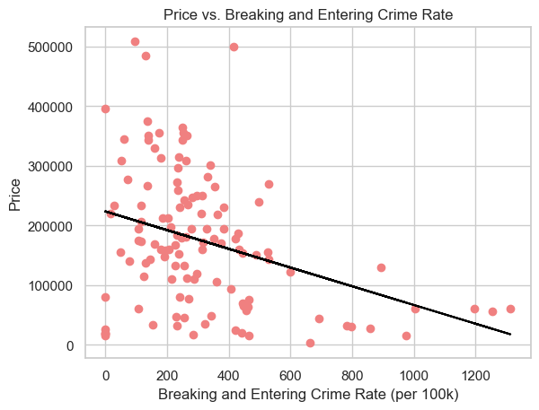

```python
slope, intercept = np.polyfit(my_crime_df["BNE_Per_100k"],my_crime_df["Price"],1)
plt.pyplot.plot(my_crime_df["BNE_Per_100k"],slope*my_crime_df["BNE_Per_100k"]+intercept,color='black')
plt.pyplot.scatter(x=my_crime_df["BNE_Per_100k"],y=my_crime_df["Price"],color="lightcoral")
plt.pyplot.ylabel("Price")
plt.pyplot.xlabel("Breaking and Entering Crime Rate (per 100k)")
plt.pyplot.title("Price vs. Breaking and Entering Crime Rate")
plt.pyplot.show()
```

The line represents the linear fit of the data (showing the correlation (linear)). As we can see, there seems to be a slight curved relationship rather than a linear one with this plot. However, there seems to be at least sort of a relationship between price and breaking and entering crime rates.

This is well... ok news. The correlation is not strong, but hopefully we will be able to see more how crime rates might affect the prices in the next section.

### So, what have we observed with our three statistical methods:

By observing the differences in the crime data and how most counties vary significantly in their crime data by jurisdiction, we know that our jurisdiction data is important, and that we shouldn't ignore it. This is important for us to know while building our model.

By observing the differences in the median between counties, we understand that different counties sell houses for different values, in general, and we vary in price by county. Further, we see that we have a lot of outliers with extreme house prices. We now know that we have to devise a way to deal with these outliers before starting our machine learning.

By observing the correlation between different crimes and house prices, we can see which crime data points have a high correlation with each other, and which crime data points have a correlation with the price. We now understand the importance of non-linear prediction, and know that we can remove some of the extra features in the crime dataset that are highly correlated. Finally, we understand that the breaking and entering crime data is likely the most important.

We are now ready to prepare for machine learning.

## Machine Learning (prediction)

It is finally time for machine learning. We will now combine our datasets, keep certain features based on what we need, and normalize price data based on inflation.

#### Final Pre-Processing

First, we will get rid of our outliers in the real estate data. We will use the standard definition of outliers (upper fence). See Exploring home prices by county (over the years) in the Data Exploration section if you want more information on what upper fence means. Also see https://www.statology.org/upper-and-lower-fences/.  
But first, we will get rid of 0-values in the price. They will skew our data. No real esatate is worth 0 dollars.

```python
final_estate_df = final_estate_df[final_estate_df["Price"]!=0.0]
final_estate_df = final_estate_df[final_estate_df["Final_Price"]!=0.0]
```

Now we will adjust prices for inflation. We are adjusting before getting rid of outliers because the adjustment will affect which points are considered outliers, as some of the upper outliers will disappear once adjusted for crazy inflation. (1 million dollars for a home in 2024 is the same as 262 thousand dollars in 1980).

First, let's account for inflation in our price data. In order for this adjustment, we will create a list of inflation adjusted data and then add it back to the dataframe.

```python
# We are making the date the index, and then we are creating a dictionary where the keys are the date, and the values are the inflation index.
inflation_dictionary = final_inflation_df.set_index("Date").to_dict()
inflation_dictionary = inflation_dictionary['Inflation_Index']

# Missing value, taking from https://www.usinflationcalculator.com/inflation/consumer-price-index-and-annual-percent-changes-from-1913-to-2008/
inflation_dictionary['2024']=308

# Create the necessary lists in order to make the new columns
my_inflated_values_price=[]
my_inflated_values_final_price=[]
my_price = final_estate_df["Price"].to_list()
my_final_price = final_estate_df["Final_Price"].to_list()

# Loop through the dataframe, going through the dates of the 'price' feature
for index, date in enumerate(final_estate_df["Date_1"].to_list()):
    if (str(date) not in inflation_dictionary.keys()):
        my_inflated_values_price.append(0.0)
    else:
        my_inflated_values_price.append(my_price[index]/inflation_dictionary[str(date)])

# Loop through the dataframe, going through the dates of the 'final_price' feature
for index, date in enumerate(final_estate_df["Date_2"].to_list()):
    # If there is a date that is outside the scope of 1947-2024, it should be removed
    if (str(date) not in inflation_dictionary.keys()):
        my_inflated_values_final_price.append(0.0)
    else:
        my_inflated_values_final_price.append(my_final_price[index]/inflation_dictionary[str(date)])

final_estate_df["Price"]=my_inflated_values_price
final_estate_df["Final_Price"]=my_inflated_values_final_price
final_estate_df = final_estate_df[final_estate_df["Price"]!=0.0]
final_estate_df = final_estate_df[final_estate_df["Final_Price"]!=0.0]
```

Now that we have adjusted for inflation, let's take the upper fence and take away all outliers above it. We do not need our model to be greatly skewed by a billion dollar deal on multiple homes.

```python
price_upper_fence = 1.5*(final_estate_df["Price"].quantile(.75)-final_estate_df["Price"].quantile(.25))+final_estate_df["Price"].quantile(.75)
final_price_upper_fence = 1.5*(final_estate_df["Final_Price"].quantile(.75)-final_estate_df["Final_Price"].quantile(.25))+final_estate_df["Final_Price"].quantile(.75)
final_estate_df = final_estate_df[final_estate_df["Price"]<price_upper_fence]
final_estate_df = final_estate_df[final_estate_df["Final_Price"]<final_price_upper_fence]
```

Great! Now we have adjusted our data for inflation. The only thing left is to add crime data based on municipality. If the municipality does not exist in our crime dataset, we will use the county average data for that year.

```python
final_crime_df["Year"]=final_crime_df["Year"].astype(str)
final_crime_df["CountyYear"]=final_crime_df["County"]+final_crime_df["Year"]
final_crime_df["CityYear"]=final_crime_df["Jurisdiction"]+final_crime_df["Year"]
```

```python
county_crime_dict = final_crime_df.groupby("CountyYear")[[
       'Violent_Crime_Percent', 'Property_Crime_Percent',
       'Overall_Rate_Per_100k', 'Violent_Rate_Per_100k',
       'Property_Rate_Per_100k', 'Murder_Per_100k', 'Rape_Per_100k',
       'Robbery_Per_100k', 'Agg_Assault_Per_100k', 'BNE_Per_100k',
       'Larceny_Per_100k', 'MV_Theft_Per_100k', 'Crime_Percent']].median().to_dict()
```

```python
final_crime_dict=final_crime_df.to_dict('list')
```

Before we continue, we have to remember that our crime data only goes from 1990 to 2022. Thus, we have to discard any real estate data from outside of that time.

```python
final_dict = final_estate_df[(final_estate_df["Date_2"]<2023) & (final_estate_df["Date_1"]>1989)].to_dict('list')
```

```python
final_estate_df.head()
```

|  | City | County | Date_1 | Date_2 | Price | Final_Price |
| --- | --- | --- | --- | --- | --- | --- |
| 2 | Earleville | Cecil County | 2019 | 2022 | 306.746032 | 274.113475 |
| 5 | Earleville | Cecil County | 2019 | 2022 | 30.952381 | 27.659574 |
| 7 | Earleville | Cecil County | 1991 | 2019 | 462.686567 | 479.630952 |
| 8 | Earleville | Cecil County | 2019 | 2022 | 479.630952 | 433.687943 |
| 10 | Earleville | Cecil County | 1991 | 2019 | 462.686567 | 19.444444 |

We will now combine our datasets! Let's do it with some good ol' Python dictionaries.

```python
# Create a dictionary to hold the crime and price data
my_final_dict = {}
my_final_dict["County"]=[]
my_final_dict["City"]=[]
my_final_dict["Date_1"]=[]
my_final_dict["Date_2"]=[]
my_final_dict["Price"]=[]
my_final_dict["Final_Price"]=[]
my_final_dict["Property_Rate_Per_100k"]=[]
my_final_dict["Murder_Per_100k"]=[]
my_final_dict["Rape_Per_100k"]=[]
my_final_dict["Robbery_Per_100k"]=[]
my_final_dict["Agg_Assault_Per_100k"]=[]
my_final_dict["BNE_Per_100k"]=[]
my_final_dict["Larceny_Per_100k"]=[]
my_final_dict["MV_Theft_Per_100k"]=[]
my_final_dict["Crime_Percent"]=[]

# Loop through every county
for index, city in enumerate(final_dict["City"]):
    year1=final_dict["Date_1"][index]
    year2=final_dict["Date_2"][index]
    county=final_dict["County"][index]
    price=final_dict["Price"][index]
    final_price=final_dict["Final_Price"][index]
    # Get rid of the word "county" after every single county (doesn't exist for Baltimore City)
    if (county!="Baltimore City"):
        county=county[:-7]
    cityyear1=city+str(year1)
    countyyear1=county+str(year1)
    cityyear2=city+str(year2)
    countyyear2=county+str(year2)
    if ((cityyear1 not in final_crime_dict["CityYear"]) or (cityyear2 not in final_crime_dict["CityYear"])):
        prop1=county_crime_dict["Property_Rate_Per_100k"][countyyear1]
        murder1=county_crime_dict["Murder_Per_100k"][countyyear1]
        rape1=county_crime_dict["Rape_Per_100k"][countyyear1]
        robbery1=county_crime_dict["Robbery_Per_100k"][countyyear1]
        agg1=county_crime_dict["Agg_Assault_Per_100k"][countyyear1]
        bne1=county_crime_dict["BNE_Per_100k"][countyyear1]
        lar1=county_crime_dict["Larceny_Per_100k"][countyyear1]
        mv1=county_crime_dict["MV_Theft_Per_100k"][countyyear1]
        crp1=county_crime_dict["Crime_Percent"][countyyear1]

        prop2=county_crime_dict["Property_Rate_Per_100k"][countyyear2]
        murder2=county_crime_dict["Murder_Per_100k"][countyyear2]
        rape2=county_crime_dict["Rape_Per_100k"][countyyear2]
        robbery2=county_crime_dict["Robbery_Per_100k"][countyyear2]
        agg2=county_crime_dict["Agg_Assault_Per_100k"][countyyear2]
        bne2=county_crime_dict["BNE_Per_100k"][countyyear2]
        lar2=county_crime_dict["Larceny_Per_100k"][countyyear2]
        mv2=county_crime_dict["MV_Theft_Per_100k"][countyyear2]
        crp2=county_crime_dict["Crime_Percent"][countyyear2]
    else:
        index1=final_crime_dict["CityYear"].index(cityyear1)

        prop1=final_crime_dict["Property_Rate_Per_100k"][index1]
        murder1=final_crime_dict["Murder_Per_100k"][index1]
        rape1=final_crime_dict["Rape_Per_100k"][index1]
        robbery1=final_crime_dict["Robbery_Per_100k"][index1]
        agg1=final_crime_dict["Agg_Assault_Per_100k"][index1]
        bne1=final_crime_dict["BNE_Per_100k"][index1]
        lar1=final_crime_dict["Larceny_Per_100k"][index1]
        mv1=final_crime_dict["MV_Theft_Per_100k"][index1]
        crp1=final_crime_dict["Crime_Percent"][index1]

        index2=final_crime_dict["CityYear"].index(cityyear2)

        prop2=final_crime_dict["Property_Rate_Per_100k"][index2]
        murder2=final_crime_dict["Murder_Per_100k"][index2]
        rape2=final_crime_dict["Rape_Per_100k"][index2]
        robbery2=final_crime_dict["Robbery_Per_100k"][index2]
        agg2=final_crime_dict["Agg_Assault_Per_100k"][index2]
        bne2=final_crime_dict["BNE_Per_100k"][index2]
        lar2=final_crime_dict["Larceny_Per_100k"][index2]
        mv2=final_crime_dict["MV_Theft_Per_100k"][index2]
        crp2=final_crime_dict["Crime_Percent"][index2]

    # Add the difference between the crime rates to the new dataframe
    my_final_dict["County"].append(county)
    my_final_dict["City"].append(city)
    my_final_dict["Date_1"].append(year1)
    my_final_dict["Date_2"].append(year2)
    my_final_dict["Price"].append(price)
    my_final_dict["Final_Price"].append(final_price)
    my_final_dict["Property_Rate_Per_100k"].append(prop2-prop1)
    my_final_dict["Murder_Per_100k"].append(murder2-murder1)
    my_final_dict["Rape_Per_100k"].append(rape2-rape1)
    my_final_dict["Robbery_Per_100k"].append(robbery2-robbery1)
    my_final_dict["Agg_Assault_Per_100k"].append(agg2-agg1)
    my_final_dict["BNE_Per_100k"].append(bne2-bne1)
    my_final_dict["Larceny_Per_100k"].append(lar2-lar1)
    my_final_dict["MV_Theft_Per_100k"].append(mv2-mv1)
    my_final_dict["Crime_Percent"].append(crp2-crp1)
```

```python
final_df = pd.DataFrame.from_dict(my_final_dict)
```

```python
final_df.sample(3)
```

|  | County | City | Date_1 | Date_2 | Price | Final_Price | Property_Rate_Per_100k | Murder_Per_100k | Rape_Per_100k | Robbery_Per_100k | Agg_Assault_Per_100k | BNE_Per_100k | Larceny_Per_100k | MV_Theft_Per_100k | Crime_Percent |
| --- | --- | --- | --- | --- | --- | --- | --- | --- | --- | --- | --- | --- | --- | --- | --- |
| 2151110 | Baltimore City | Parkville | 2012 | 2019 | 594.713656 | 704.892857 | -484.7 | 23.0 | 2.8 | 220.9 | 175.9 | -352.2 | -145.7 | 13.2 | -0.000621 |
| 389546 | Prince George's | Hyattsville | 2004 | 2019 | 698.924731 | 886.904762 | 405.5 | 8.8 | 3.4 | -127.7 | -78.6 | -436.0 | 1933.2 | -1091.6 | 0.002115 |
| 678787 | Worcester | Berlin | 2006 | 2008 | 1446.733668 | 1292.452830 | -745.3 | 24.9 | 0.0 | 72.5 | 215.6 | 30.2 | -719.8 | -55.7 | -0.004323 |

```python
final_df.groupby("County")["Price"].median().sort_values()
```

```
County
Somerset            246.728272
Allegany            304.147465
Garrett             325.793651
Baltimore City      444.029851
Dorchester          476.190476
Wicomico            534.545855
Kent                596.694444
Caroline            633.730159
Cecil               702.803983
Washington          772.091270
Worcester           858.757062
Baltimore           866.995074
Talbot              970.464135
Harford            1000.000000
St. Mary's         1002.102737
Prince George's    1043.956044
Queen Anne's       1082.131494
Calvert            1130.653266
Charles            1157.213438
Anne Arundel       1244.593074
Carroll            1246.276888
Frederick          1327.683616
Montgomery         1507.537688
Howard             1529.107033
Name: Price, dtype: float64
```

We will split the counties by median price and use those rather than the county or jurisdiction name for our final data (as we cannot have categorical data) in our final dataset.

```python
final_df.loc[final_df["County"]=="Somerset","County"]=1; final_df.loc[final_df["County"]=="Allegany","County"]=1; final_df.loc[final_df["County"]=="Garrett","County"]=1;
final_df.loc[final_df["County"]=="Baltimore City","County"]=2; final_df.loc[final_df["County"]=="Dorchester","County"]=2; final_df.loc[final_df["County"]=="Wicomico","County"]=2;
final_df.loc[final_df["County"]=="Kent","County"]=3; final_df.loc[final_df["County"]=="Caroline","County"]=3; final_df.loc[final_df["County"]=="Cecil","County"]=3;
final_df.loc[final_df["County"]=="Washington","County"]=4; final_df.loc[final_df["County"]=="Worcester","County"]=4; final_df.loc[final_df["County"]=="Baltimore","County"]=4;
final_df.loc[final_df["County"]=="Talbot","County"]=5; final_df.loc[final_df["County"]=="Harford","County"]=5; final_df.loc[final_df["County"]=="St. Mary's","County"]=5;
final_df.loc[final_df["County"]=="Prince George's","County"]=6; final_df.loc[final_df["County"]=="Queen Anne's","County"]=6; final_df.loc[final_df["County"]=="Calvert","County"]=6;
final_df.loc[final_df["County"]=="Charles","County"]=7; final_df.loc[final_df["County"]=="Anne Arundel","County"]=7; final_df.loc[final_df["County"]=="Carroll","County"]=7;
final_df.loc[final_df["County"]=="Frederick","County"]=8; final_df.loc[final_df["County"]=="Montgomery","County"]=8; final_df.loc[final_df["County"]=="Howard","County"]=8;
```

Let's make sure that the type is correct for this labeled data.

```python
final_df["County"]=final_df["County"].astype(int)
```

We no longer need the jurisdiction data, so we will just drop it.

```python
final_df.drop("City",axis='columns',inplace=True)
```

```python
final_df.sample(3)
```

|  | County | Date_1 | Date_2 | Price | Final_Price | Property_Rate_Per_100k | Murder_Per_100k | Rape_Per_100k | Robbery_Per_100k | Agg_Assault_Per_100k | BNE_Per_100k | Larceny_Per_100k | MV_Theft_Per_100k | Crime_Percent |
| --- | --- | --- | --- | --- | --- | --- | --- | --- | --- | --- | --- | --- | --- | --- |
| 81397 | 7 | 2019 | 2022 | 1894.841270 | 1825.177305 | -1427.85 | 6.5 | -57.7 | -119.4 | -178.85 | -128.95 | -1331.60 | 32.8 | -0.017774 |
| 522215 | 8 | 2019 | 2022 | 1644.972222 | 1590.070922 | 808.25 | 1.8 | 24.5 | 22.7 | 129.55 | 104.10 | 669.15 | 35.0 | 0.009253 |
| 1969977 | 2 | 1991 | 1998 | 544.029851 | 505.555556 | -2817.50 | -14.3 | 3.0 | -42.3 | -168.80 | -323.10 | -2752.30 | 258.0 | -0.030400 |

Our data is finally ready for us to make a machine learning model for predicting the price data. Now for the fun stuff!

#### Splitting and Normalizing the Data

We will be using the train_test_split function and StandardScaler from the scikit-learn package. The train_test_split function splits the data into training and testing sets. We split data into training and testing sets so that we can see if our model will work on data that it has never seen before (test set). We will be using 20% of our data for our testing.

```python
scaler = StandardScaler()
features = scaler.fit_transform(final_df.loc[:,final_df.columns != "Final_Price"])
answer = final_df["Final_Price"]
X_train, X_test, y_train, y_test = train_test_split(features, answer, test_size=0.20)

# PyTorch only accepts tensors, so let's change the type of our data to PyTorch tensors
X_train = torch.tensor(X_train, dtype=torch.float32)
y_train = torch.tensor(y_train.values, dtype=torch.float32).reshape(-1,1)
X_test = torch.tensor(X_test, dtype=torch.float32)
y_test = torch.tensor(y_test.values, dtype=torch.float32).reshape(-1,1)
```

#### Building and Training the Model

```python
my_model = torch.nn.Sequential(
  # We start with 13 feature columns, so that's why we start with 13 nodes
  torch.nn.Linear(in_features=13, out_features=26),
  torch.nn.LeakyReLU(), # we are going to use the leaky version because it prevents vanishing gradients
  torch.nn.Linear(in_features=26, out_features=50),
  torch.nn.LeakyReLU(),
  torch.nn.Linear(in_features=50, out_features=24),
  torch.nn.LeakyReLU(),
  torch.nn.Linear(in_features=24, out_features=15),
  torch.nn.LeakyReLU(),
  torch.nn.Linear(in_features=15, out_features=1)
)

learning_rate=.000006

# Use mean absolute error
my_mae = torch.nn.L1Loss()

# We will be using the Adam optimizer (commonly used)
my_optimizer = torch.optim.Adam(my_model.parameters(),lr=learning_rate)
epochs = 20
my_batch_size = 128

# Used to save the losses at different points so we can graph it
save_loss=[]

# Model training
my_model.train()
for epoch in range(epochs):
  for number in range(0,len(X_train), my_batch_size):
    # Predict for batch
    prediction = my_model(X_train[number:(number+my_batch_size)])
    # Get the actual values for batch
    actual = y_train[number:(number+my_batch_size)]

    # Calculate loss for batch
    loss = my_mae(prediction,actual)

    # Clear old gradients
    my_optimizer.zero_grad()

    # Calculate gradients
    loss.backward()

    # Save current loss
    save_loss.append(loss.item())

    # Optimize (perform gradient descent) based on batch
    my_optimizer.step()

  # Print loss at end of epoch
  print("Loss for epoch " +str(epoch+1)+ ": "+str(loss.item()))
```

```
Loss for epoch 1: 1135.474365234375
Loss for epoch 2: 964.7459106445312
Loss for epoch 3: 710.9055786132812
Loss for epoch 4: 536.7559814453125
Loss for epoch 5: 406.2646484375
Loss for epoch 6: 342.46368408203125
Loss for epoch 7: 309.76800537109375
Loss for epoch 8: 294.6148376464844
Loss for epoch 9: 283.6432189941406
Loss for epoch 10: 276.5517883300781
Loss for epoch 11: 272.3535461425781
Loss for epoch 12: 269.7596130371094
Loss for epoch 13: 267.8248596191406
Loss for epoch 14: 265.9349670410156
Loss for epoch 15: 264.4488830566406
Loss for epoch 16: 262.9721984863281
Loss for epoch 17: 261.742919921875
Loss for epoch 18: 260.4498596191406
Loss for epoch 19: 259.19622802734375
Loss for epoch 20: 258.0805358886719
```

#### Model Analysis (testing and plots)

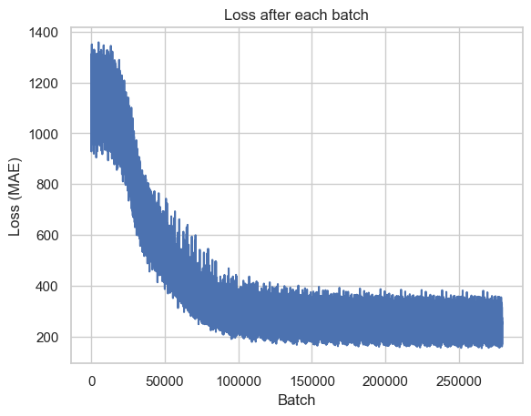

```python
plt.pyplot.plot(range(len(save_loss[100:400000])),save_loss[100:400000])
plt.pyplot.xlabel('Batch')
plt.pyplot.ylabel('Loss (MAE)')
plt.pyplot.title("Loss after each batch")
plt.pyplot.show()
```

WOW! This loss curve is beautiful. It's almost textbook. It looks this model is doing really well and has learned a lot. But let's put it to the test. Literally. How does it perform on the test data?

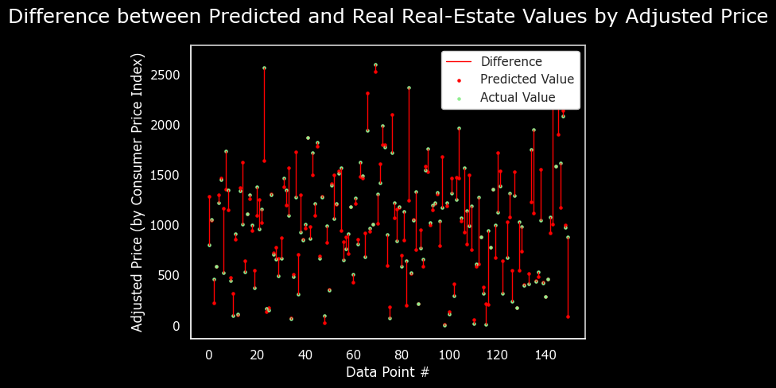

```python
plt.pyplot.rcParams["font.family"] = ['Verdana', 'sans-serif']
my_prediction = my_model(X_test)
number_of_points = 150
fig = plt.pyplot.figure()
ax = plt.pyplot.axes()

# Set whole area as black
fig.patch.set_facecolor('black')
fig.patch.set_alpha(1)

# Put a label for the lines (see later)
plt.pyplot.plot((0,0),(0,0),c='red',lw=1,label="Difference")

# Set black background
ax.set_facecolor("black")

# Plot points (prediction vs actual)
plt.pyplot.scatter(x=range(len(my_prediction.tolist()[0:number_of_points])),y=my_prediction.tolist()[0:number_of_points],color='red',s=5, label="Predicted Value")
plt.pyplot.scatter(x=range(len(y_test.tolist()[0:number_of_points])),y=y_test.tolist()[0:number_of_points],color='lightgreen',s=5,label="Actual Value")
my_values=[]
test_values=[]

# Create lists for red lines
for value in my_prediction.tolist()[0:number_of_points]:
    my_values.append(value[0]);
for value in y_test.tolist()[0:number_of_points]:
    test_values.append(value[0])
my_x = (range(len(my_prediction.tolist()[0:number_of_points])),range(len(my_prediction.tolist()[0:number_of_points])))
combined=(my_values,test_values)

# Add the lines
plt.pyplot.plot(my_x,combined,c='red',lw=1)

# labels
plt.pyplot.xlabel("Data Point #",color="white")
plt.pyplot.ylabel("Adjusted Price (by Consumer Price Index)",color="white")
plt.pyplot.title("Difference between Predicted and Real Real-Estate Values by Adjusted Price",color="white",fontsize=18,pad=20)
plt.pyplot.grid(False)

# Put a legend so that the user knows what is the predicted and what is the actual, and where the line goes
plt.pyplot.legend(loc="upper right",frameon=True,facecolor="white",framealpha=1)

# Make the borders white
ax.tick_params(axis='x', colors='white')
ax.tick_params(axis='y', colors='white')
ax.spines['left'].set_color('white')
ax.spines['bottom'].set_color('white')

plt.pyplot.show()
```

```python
# Calculate loss for test data (how well the model performs on real data)
loss = my_mae(my_prediction,y_test)
print("Mean Absolute Error (measure of accuracy) for test data: " + str(loss.item()))
```

```
Mean Absolute Error (measure of accuracy) for test data: 242.74285888671875
```

As we can see, there are clearly some points that have a vastly different value than expected, but such is the world of real-estate. Although we still have a fairly large difference in accuracy for the test data, we recognize that the mean absolute error is an average (mean) of the error. That means that when there are large differences in the data (say a disaster takes out a house), this event gets factored into the accuracy.

Something to notice about our visual is that we have some very, very good predictions that are almost right on the money. It seems that in general, our model can successfully predict the movement of house prices with crime data pretty well in a standard case. Let's see if it works on some real-world data. Fun fact, this information is about my neighbor's recently sold home. Please don't use it maliciously :).

#### Real-World Single Example

This is data on my neighbor's recently sold home.

```python
my_house={}
my_house["County"]=[]
my_house["Date_1"]=[]
my_house["Date_2"]=[]
my_house["Price"]=[]
my_house["Final_Price"]=[]
my_house["Property_Rate_Per_100k"]=[]
my_house["Murder_Per_100k"]=[]
my_house["Rape_Per_100k"]=[]
my_house["Robbery_Per_100k"]=[]
my_house["Agg_Assault_Per_100k"]=[]
my_house["BNE_Per_100k"]=[]
my_house["Larceny_Per_100k"]=[]
my_house["MV_Theft_Per_100k"]=[]
my_house["Crime_Percent"]=[]
my_house_df = pd.DataFrame.from_dict(my_house)

index=0
year1=2006
year2=2018
county="Baltimore"
price=315000
final_price=295000
countyyear1=county+str(year1)
countyyear2=county+str(year2)
prop1=county_crime_dict["Property_Rate_Per_100k"][countyyear1]
murder1=county_crime_dict["Murder_Per_100k"][countyyear1]
rape1=county_crime_dict["Rape_Per_100k"][countyyear1]
robbery1=county_crime_dict["Robbery_Per_100k"][countyyear1]
agg1=county_crime_dict["Agg_Assault_Per_100k"][countyyear1]
bne1=county_crime_dict["BNE_Per_100k"][countyyear1]
lar1=county_crime_dict["Larceny_Per_100k"][countyyear1]
mv1=county_crime_dict["MV_Theft_Per_100k"][countyyear1]
crp1=county_crime_dict["Crime_Percent"][countyyear1]

prop2=county_crime_dict["Property_Rate_Per_100k"][countyyear2]
murder2=county_crime_dict["Murder_Per_100k"][countyyear2]
rape2=county_crime_dict["Rape_Per_100k"][countyyear2]
robbery2=county_crime_dict["Robbery_Per_100k"][countyyear2]
agg2=county_crime_dict["Agg_Assault_Per_100k"][countyyear2]
bne2=county_crime_dict["BNE_Per_100k"][countyyear2]
lar2=county_crime_dict["Larceny_Per_100k"][countyyear2]
mv2=county_crime_dict["MV_Theft_Per_100k"][countyyear2]
crp2=county_crime_dict["Crime_Percent"][countyyear2]

my_house["County"].append(county)
my_house["Date_1"].append(year1)
my_house["Date_2"].append(year2)
my_house["Price"].append(price)
my_house["Final_Price"].append(final_price)
my_house["Property_Rate_Per_100k"].append(prop2-prop1)
my_house["Murder_Per_100k"].append(murder2-murder1)
my_house["Rape_Per_100k"].append(rape2-rape1)
my_house["Robbery_Per_100k"].append(robbery2-robbery1)
my_house["Agg_Assault_Per_100k"].append(agg2-agg1)
my_house["BNE_Per_100k"].append(bne2-bne1)
my_house["Larceny_Per_100k"].append(lar2-lar1)
my_house["MV_Theft_Per_100k"].append(mv2-mv1)
my_house["Crime_Percent"].append(crp2-crp1)
my_house["Price"]=my_house["Price"][0]/inflation_dictionary[str(year1)]
my_house["Final_Price"]=my_house["Final_Price"][0]/inflation_dictionary[str(year2)]
my_house_df=pd.DataFrame.from_dict(my_house)
my_house_df.loc[my_house_df["County"]=="Baltimore","County"]=4;
```

```python
prediction=my_model(torch.tensor(scaler.transform(my_house_df.loc[:,my_house_df.columns != "Final_Price"]), dtype=torch.float32))
actual=my_house_df["Final_Price"]
print("Price in 2006: "+str(my_house_df["Price"].values[0]))
print("Predicted Price for 2018: "+str(prediction[0][0].item()))
print("Actual Value in 2018: "+str(actual.values[0]))
```

```
Price in 2006: 1582.9145728643216
Predicted Price for 2018: 1379.4776611328125
Actual Value in 2018: 1189.516129032258
```

Ok, so the model isn't the best at it, but it did predict the price decrease. This model is very rudimentary. While it can predict some sort of price movements, it needs a lot of work. Obviously, there are a lot more elements that go into a house price other than just the county's crime rates and the current year.

## Insights and Conclusions

When we started off this document, we asked the question: Is there a relationship between crime rates and house prices in different municipalities in the state of Maryland?

Based on our data analysis, and our machine learning, we can say that yes, there is some sort of relationship between crime rates and house prices based on municipality. We have observed this with tests, charts, and analysis.

Thank you for letting me take you on a data science and analytics journey.

Until we meet again :).

## Additional Readings

There's loads of great materials out there for learning more about data science, but I'm here to suggest a few. A Google search or YouTube search have also proved to be very valuable tools. If you're ever confused on a topic, I would highly recommend searching for it on Google first. Someone, somewhere, has also been confused. I often get confused, so take it from me. Or don't :).

Really good article that takes you from Step 1 to having data ready for a machine learning model. https://www.geeksforgeeks.org/data-preprocessing-in-data-mining/

Information on Hypothesis Testing (we performed a hypothesis test earlier). https://www.statisticshowto.com/probability-and-statistics/hypothesis-testing/

Information on correlation. https://www.jmp.com/en_us/statistics-knowledge-portal/what-is-correlation.html

More information on neural networks. (from general explanation to math explanation, very good) https://www.ibm.com/topics/neural-networks

More information on activation functions and LReLu (leaky relu). https://www.sciencedirect.com/topics/computer-science/leaky-rectified-linear-unit#:~:text=Leaky%20ReLU%20has%20a%20small,speed%2Dup%20the%20training%20process.

More information on grid-search/model tuning. https://scikit-learn.org/stable/modules/grid_search.html

Color Theory? Really? Yes. Color choice (palette) is essential for good design, especially for plots and visuals. https://careerfoundry.com/en/blog/ui-design/introduction-to-color-theory-and-color-palettes/#:~:text=Commonly%2C%20color%20palettes%20are%20made,is%20usually%20black%20or%20grey).